# Money and Success in Football

Does Financial Strength Predict League Position? *Sports Economics Seminar — Summer Semester 2026

Md. Muktadir

July 11, 2026

# 1 Executive Summary

**Scale of the study:** 976 team-seasons across 5 major European leagues (Bundesliga, La Liga, Ligue 1, Premier League, Serie A) covering 10 seasons (2015–16 to 2024–25). All leagues and seasons are included in the analysis.

**Core finding:** The Pearson correlation between Financial Rank and final league position is **r = 0.813** (Spearman ρ = 0.814, both *p* < 0.001). The best-fitting model — Model H, which adds a quadratic (squared) term to Financial Rank — explains **R² = 0.671** of all variation in final standings. In plain terms, knowing only how wealthy a club is relative to its peers allows us to correctly explain **67%** of where they finish.

**Extended robustness (Step 7):** the core finding is additionally stress-tested against a two-period time split, an alternative outcome variable (points instead of position), and a cross-sport comparison with the NBA’s salary-capped league. It survives all three — though the NBA comparison shows that a hard salary cap can meaningfully weaken, without eliminating, the link between spending and winning.

# 2 Introduction

## 2.1 Why Does This Question Matter?

The five major European football leagues — the English Premier League, Spanish La Liga, German Bundesliga, Italian Serie A, and French Ligue 1 — collectively generate over €18 billion in annual revenue, with squad transfer spending exceeding €12 billion in recent seasons. With this much money flowing through the sport, a natural and important question arises: **does financial investment actually buy success, or can a well-organised, under-funded club systematically compete at the top level?**

This question is not just about football. It has direct implications for:

- **Competitive balance policy** — UEFA introduced Financial Fair Play precisely to prevent the wealthiest clubs from buying their way to dominance. If money truly determines outcomes, these policies become even more critical.
- **Fan engagement** — If leagues are financially predetermined, the drama of competition is diminished for supporters of smaller clubs.
- **Sports economics theory** — Understanding how resource endowments translate to tournament outcomes informs models across all competitive sports.

## 2.2 What We Set Out to Answer

This study addresses three interrelated questions using ten years of data from all five top-tier European leagues:

1. **Direction and strength:** Is there a statistically significant relationship between a squad’s financial rank within its league and its final position? How strong is that relationship?
2. **Model form:** Does a simple linear relationship capture the data, or is there a more complex (e.g., non-linear) pattern? Does the relationship differ across leagues or change over time?
3. **Exceptions:** Which clubs defy the financial hierarchy, and how statistically unusual are they? Is Leicester City 2015–16 a miracle or merely a rounding error?

## 2.3 What This Study Adds

Previous research (Szymanski & Kuypers, 1999; Frick, 2007) has shown that wage bills and transfer spending predict league success. This study makes two additional contributions. First, instead of raw market values, we use a **within-league financial rank** — which club was the *n*-th wealthiest in their specific league that season. This removes the scale problem: a €300M squad is the richest in Ligue 1 but the fifth-richest in the Premier League. By ranking within leagues, we can pool all five leagues and make fair comparisons. Second, we introduce a **residual-based outlier framework** to systematically identify and quantify clubs that dramatically beat or missed their financial prediction.

# 3 The Data We Used

## 3.1 Where the Data Comes From

Our dataset was assembled by combining two sources:

- **ESPN FC** provided final league standings (League Position) for all five leagues across the 2015–16 through 2024–25 seasons.
- **Transfermarkt** provided squad market values — the estimated total transfer market worth of all players in each squad — at the start of each season.

After merging these two sources and removing any rows with missing values on key variables, we have a clean dataset of 976 team-season observations. Every team that played a full season in one of the five leagues during the study period appears once per season.

## 3.2 Descriptive Statistics

The table below summarises the key characteristics of the dataset, broken down by league and combined.

Sample size and position/market-value statistics by league.

| Group | N | Mean Pos. | SD Pos. | Mean MV (M EUR) | SD MV (M EUR) |
| --- | --- | --- | --- | --- | --- |
| ALL LEAGUES (combined) | 976 | 10.28 | 5.66 | 277.7 | 254.3 |
| Bundesliga | 180 | 9.50 | 5.20 | 237.2 | 205.6 |
| La Liga | 200 | 10.50 | 5.78 | 256.7 | 269.4 |
| Ligue 1 | 196 | 10.32 | 5.69 | 184.7 | 193.9 |
| Premier League | 200 | 10.50 | 5.78 | 458.0 | 303.5 |
| Serie A | 200 | 10.50 | 5.78 | 245.8 | 182.4 |

Correlation between Financial Rank and final League Position by league.

| Group | N | Pearson r (FR vs Pos.) | Spearman rho (FR vs Pos.) |
| --- | --- | --- | --- |
| ALL LEAGUES (combined) | 976 | 0.813 | 0.814 |
| Bundesliga | 180 | 0.783 | 0.783 |
| La Liga | 200 | 0.787 | 0.787 |
| Ligue 1 | 196 | 0.791 | 0.791 |
| Premier League | 200 | 0.801 | 0.801 |
| Serie A | 200 | 0.890 | 0.890 |

## 3.3 Variable Definitions

The table below defines each variable used in the analysis.

Variable definitions.

| Variable | Type | Range | Description |
| --- | --- | --- | --- |
| League_Position | Integer | 1–18/20 | Final league standing; 1 = champion, higher number = worse finish |
| Financial_Rank (FR) | Integer | 1–18/20 | Squad rank by market value within league-season; 1 = richest squad |
| Market_Value_M_EUR | Numeric | 10–3300+ | Total squad market value in millions of euros (from Transfermarkt) |
| Normalized_Value | Numeric | 0–1 | Market value normalised within league-season (min-max or value share) |
| Log_Normalized_Value | Numeric | −∞–0 | Natural log of Normalized_Value; makes the skewed distribution more symmetric |
| Champion_bin | Binary (0/1) | 0 or 1 | 1 if the team won the league title that season, 0 otherwise |
| Season_Index | Integer | 1–10 | Numeric season counter: 1 = 2015–16, 10 = 2024–25 |

**The key design choice — Financial Rank instead of raw market value:** Using Financial Rank (FR) rather than the raw €-value is crucial for a multi-league analysis. Consider: a squad worth €300M is the *richest* in Ligue 1 but only the *fifth-richest* in the Premier League. If we used raw €-values and pooled all leagues, we would be comparing apples to oranges. By ranking each squad within its own league-season, we create a fair, scale-free measure. FR = 1 always means “the wealthiest club in this league this season,” regardless of whether that squad is worth €600M or €150M.

## 3.4 How Financial Rank Is Distributed

The chart below shows the distribution of Financial Rank values across all five leagues. Since every league-season has exactly as many clubs as positions, the distribution should be near-uniform — and indeed it is. This confirms that the ranking system is clean and well-balanced across the dataset.

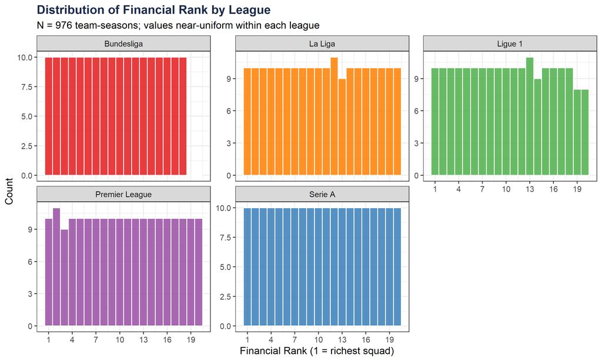

Distribution of Financial Rank across all leagues (2015-16 to 2024-25). The near-uniform distribution confirms that each rank value appears approximately equally often within every league-season.

# 4 Step 1 — First Look: Does Money Relate to Success?

## 4.1 The Main Scatter Plot

The most direct way to answer our research question is to plot Financial Rank against final League Position for all 976 team-seasons. The figure below does exactly that.

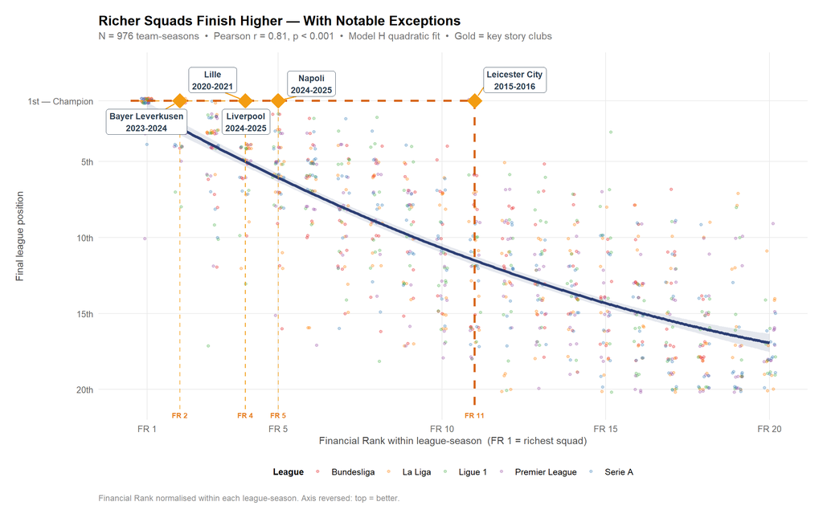

**What this plot tells us:** The downward-sloping pattern is immediately clear. Clubs with Financial Rank 1 or 2 cluster near the top of their league, while clubs with Financial Rank 15+ cluster near the bottom. The relationship is not perfect — there is considerable spread at every rank — but the trend is unmistakable. The dark fitted curve confirms this mathematically: as FR increases, predicted position gets worse, and the curve bends slightly at the bottom, suggesting the penalty for being the *poorest* club is slightly smaller than the reward for being the richest.

The Pearson correlation is **r = 0.813** and the Spearman rank correlation is ρ = 0.814 (both statistically significant at *p* < 0.001, *N* = 976). A correlation above 0.8 is considered very strong in social science contexts, and here we achieve it with a single variable.

## 4.2 Is the Relationship the Same in Every League?

A legitimate concern is whether the relationship might exist in some leagues but not others. The chart below shows the Pearson correlation and R² (variance explained) for each league separately.

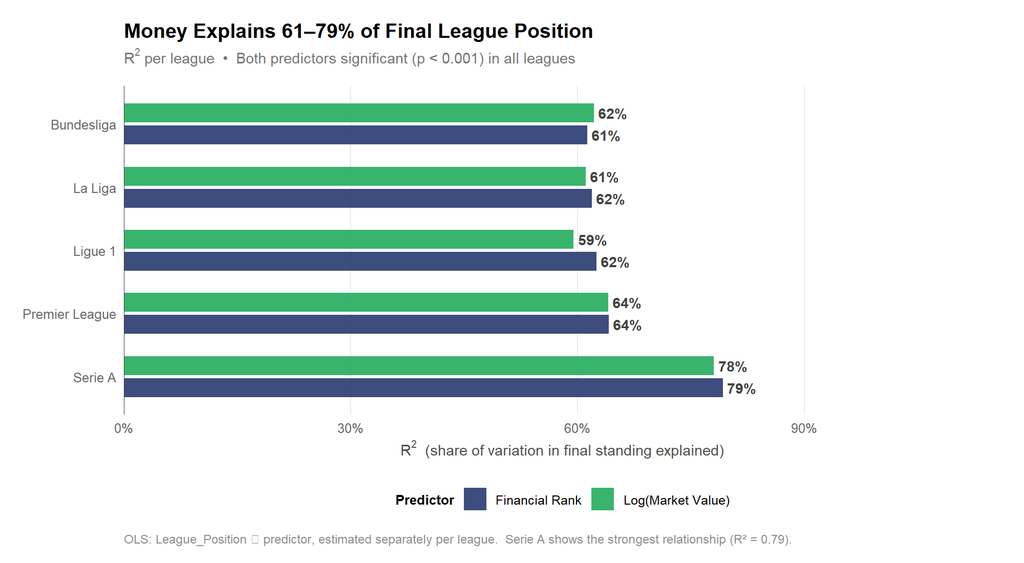

R-squared (variance explained in final position) by Financial Rank predictor, broken down by league. Financial Rank alone explains between 61% and 79% of final standings, with Serie A showing the strongest relationship.

League-level correlation and simple regression results.

| League | N | Pearson r | Spearman rho | R2 (FR) | beta(FR) |
| --- | --- | --- | --- | --- | --- |
| Bundesliga | 180 | 0.783 | 0.783 | 0.613 | 0.783 |
| La Liga | 200 | 0.787 | 0.787 | 0.619 | 0.787 |
| Ligue 1 | 196 | 0.791 | 0.791 | 0.625 | 0.791 |
| Premier League | 200 | 0.801 | 0.801 | 0.641 | 0.800 |
| Serie A | 200 | 0.890 | 0.890 | 0.792 | 0.890 |

## 4.3 Relationship by League: Faceted View

The figure below shows the scatter of Financial Rank vs. League Position separately for each league. The gold band around each fitted line shows the 95% confidence interval. All five leagues show the same clear positive slope.

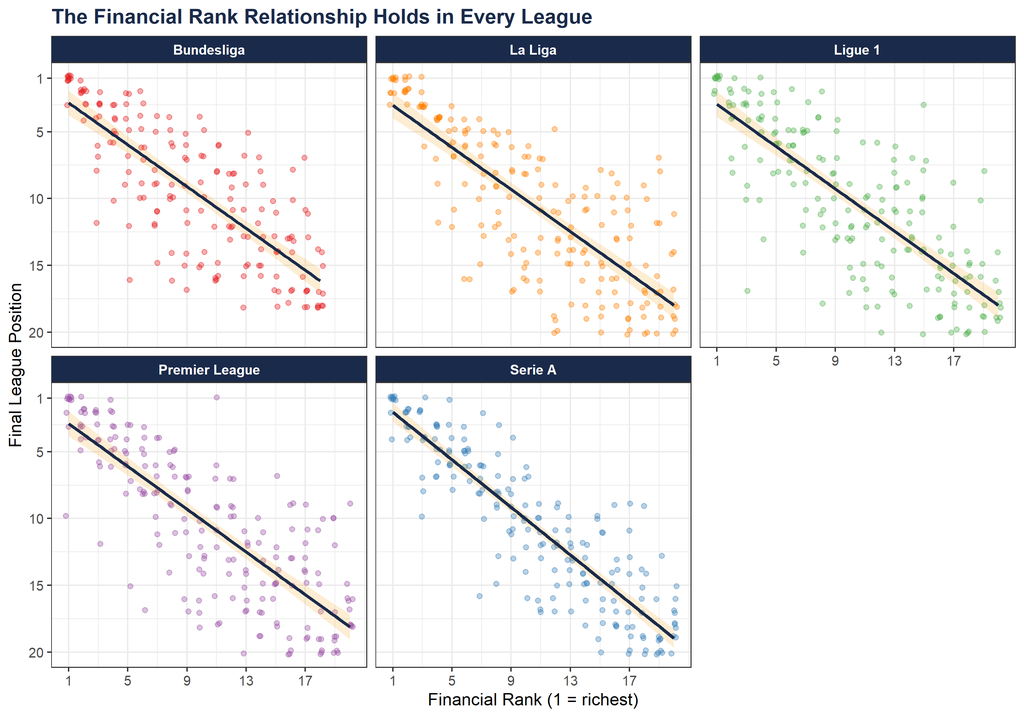

FR vs. Final League Position faceted by league, with individual linear fits. The slope and significance are consistent across all five leagues.

# 5 Step 2 — Building the Best Predictive Model

## 5.1 Our Strategy: Try Multiple Models, Compare, Pick the Best

A correlation tells us there is a relationship, but it does not give us a predictive model or tell us the precise form of the relationship. To go further, we fit a series of OLS (Ordinary Least Squares) regression models. The idea is to start simple and progressively add complexity, then compare the models formally to choose the best one.

The table below summarises the five model specifications we tested:

| Step | Question being asked | Model |
| --- | --- | --- |
| Baseline | Does FR alone predict position? | A: Position ~ FR |
| League FE | Does adding league intercepts help? | B: Position ~ FR + League |
| Alternative | Is log(Market Value) better than FR? | C: Position ~ Log(MV) |
| Full alternative | Log(MV) + league + time controls | D: Position ~ Log(MV) + League + Season |
| Non-linear | Does a curved (quadratic) fit help? | **H: Position ~ FR + FR²** |

Model selection uses AIC (Akaike Information Criterion) — a lower AIC means a better trade-off between fit and model complexity. We also report R² and adjusted R² for completeness, and verify our preferred model with formal F-tests.

## 5.2 Model Comparison Results

Model comparison. (*) = preferred specification (lowest AIC among OLS models).

| Model | Formula | R² | Adj. R² | AIC | BIC |
| --- | --- | --- | --- | --- | --- |
| A | FR | 0.6606 | 0.6602 | 5104.4 | 5119.1 |
| B | FR + League FE | 0.6607 | 0.659 | 5112.0 | 5146.2 |
| C | Log(MV) | 0.5331 | 0.5327 | 5415.5 | 5430.2 |
| D | Log(MV) + League + Season | 0.6412 | 0.639 | 5168.5 | 5207.6 |
| G | FR x League | 0.6624 | 0.6593 | 5115.1 | 5168.8 |
| H | FR + FR-sq (*) | 0.6713 | 0.6706 | 5075.1 | 5094.7 |
| H2 | FR + FR-sq + League | 0.6717 | 0.6697 | 5081.9 | 5120.9 |
| H3 | FR + FR-sq + Season | 0.6713 | 0.6703 | 5077.1 | 5101.5 |
| H4 | FR + FR-sq + League + Season | 0.6717 | 0.6693 | 5083.8 | 5127.8 |
| I | FR + FR-sq + FR-cub | 0.6713 | 0.6703 | 5076.9 | 5101.4 |
| J | Log(FR) | 0.6260 | 0.6256 | 5199.0 | 5213.6 |
| M | sqrt(FR) | 0.6689 | 0.6685 | 5080.2 | 5094.9 |
| E | Champion ~ FR (Logit) | 0.5478 | — | 182.4 | — |

Note:  
OLS: League_Position (1=champion). Model E R² is McFadden pseudo-R²; Adj. R² and BIC undefined for logit (—). (*) Model H preferred; H2/H3/H4 have higher AIC.

Model I adds a cubic term but does not significantly improve fit over Model H (see Section 9.1). Models J and M are simpler one-term alternatives that also capture diminishing returns in a different mathematical form, but both produce higher AIC than Model H.

The quadratic specification is therefore statistically optimal among all tested forms and is theoretically motivated by the principle of diminishing returns to financial advantage at the top of the financial hierarchy.

## 5.3 What Does Model H Actually Say? (The Coefficients)

Having selected Model H as our best model, we now interpret its estimated coefficients in detail.

Model H coefficient estimates. Response: League Position (1 = champion).

| Term | Estimate | Std. Error | t-value | p-value | 95% CI |
| --- | --- | --- | --- | --- | --- |
| Intercept (α) | 0.4172 | 0.3441 | 1.212 | 2.26e-01 | [-0.2573, 1.0916] |
| Financial Rank (b1) | 1.2309 | 0.0765 | 16.093 | 7.65e-52 | [1.0810, 1.3808] |
| FR-squared (b2) | -0.0202 | 0.0036 | -5.633 | 2.32e-08 | [-0.0273, -0.0132] |

## 5.4 Visualising the Quadratic Fit

The curve below makes the non-linear relationship concrete. Notice that the predicted position drops steeply as FR moves from 1 to 5 (the top of the financial hierarchy), and more gradually from FR 10 to FR 20 (the bottom).

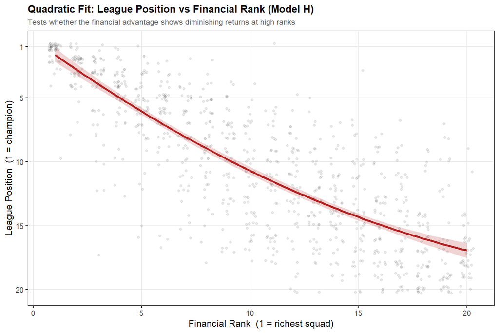

**Reading the curve:** A club ranked 1st financially is predicted to finish around 2nd place. A club ranked 5th financially is predicted to finish around 5th–6th. By FR = 10, the model predicts a mid-table finish of around 11th–12th. At FR = 20 (the poorest club in a 20-team league), the predicted finish is around 16th–17th, not 20th — this is the “diminishing returns” effect: even the poorest club is not predicted to finish stone last, because their competitors at FR 18–20 are similarly constrained.

## 5.5 How Well Does FR Explain Each League Separately?

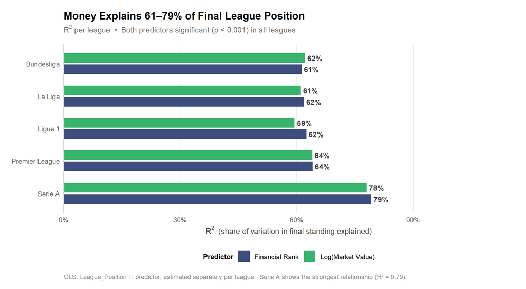

The chart confirms what Table 3 told us: Financial Rank explains 61–79% of final league position **within each individual league**, not just in the pooled analysis. Serie A shows the strongest predictability (R² = 0.79), while Ligue 1 and Bundesliga show the lowest (R² ≈ 0.61–0.64) — though even these are very high by social science standards.

# 6 Step 3 — Can We Predict Who Wins the Title?

## 6.1 A Different Question: Championship Probability

So far we have treated League Position as a continuous number and asked how Financial Rank shifts that number. But we can also ask a yes/no question: *does Financial Rank predict whether a team wins the league at all?* For this we use **logistic regression**, where the outcome is a binary variable — 1 if the team won the title, 0 otherwise (Model E).

The logistic model estimates the log-odds of winning the title as a linear function of Financial Rank:

$$\log\!\left(\frac{P(\text{Champion})}{1
- P(\text{Champion})}\right) = \alpha + \beta_{\text{FR}} \cdot
\text{FR}$$

Here, a negative β means higher FR (poorer squad) reduces the odds of winning.

Table 6. Logistic Model E coefficients. McFadden R² = 0.548, AIC = 182.4.

| Term | Log-Odds | Std. Error | z-value | p-value | Odds Ratio |
| --- | --- | --- | --- | --- | --- |
| Intercept (α) | 1.642 | 0.4033 | 4.070 | 4.70e-05 | 5.1636 |
| Financial Rank (beta) | -1.298 | 0.1900 | -6.834 | 8.24e-12 | 0.2729 |

**Interpreting the key coefficient:** The estimated β = -1.298 means that each one-step increase in Financial Rank **multiplies the odds of winning the title by** e^(-1.298) = 0.273. That is a **72.7% reduction in championship odds for every additional rank step**. Moving from FR 1 to FR 2 cuts championship odds by 72.7%; moving from FR 1 to FR 3 cuts it by nearly 92.6%.

## 6.2 The Championship Probability Curve

The figure below converts those log-odds into probabilities and plots them for every possible Financial Rank value.

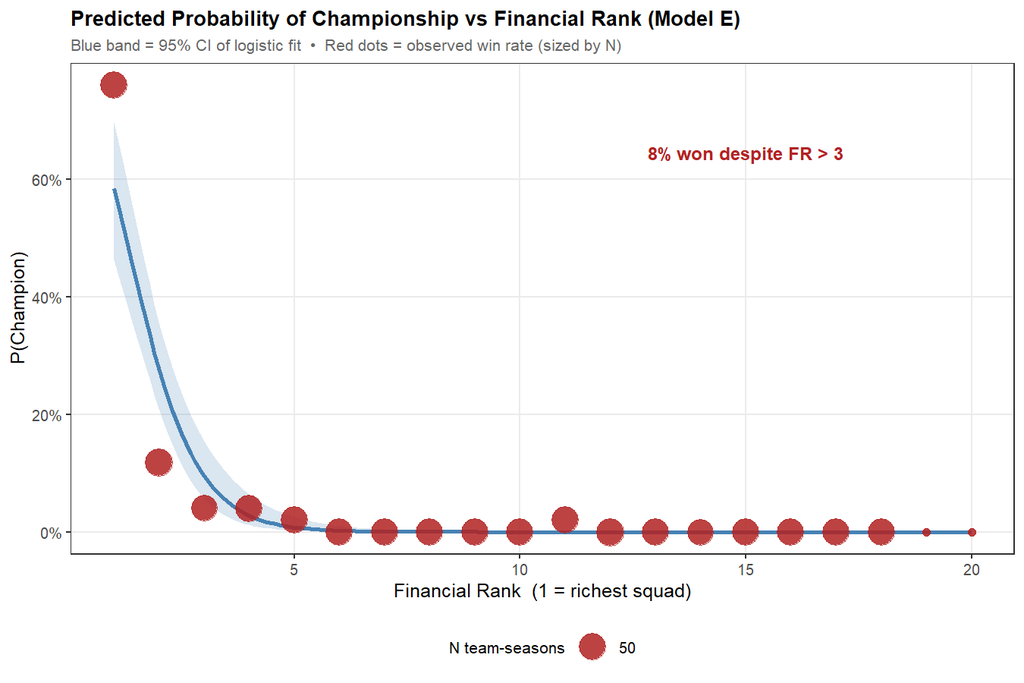

Predicted championship probabilities at key FR values (Model E).

| Financial Rank | P(Champion) |
| --- | --- |
| 1 | 58.5% |
| 2 | 27.78% |
| 3 | 9.5% |
| 4 | 2.79% |
| 5 | 0.78% |
| 8 | 0.02% |
| 11 | 0% |

**What this means in practice:** The richest club in a league (FR = 1) has a predicted championship probability of **58.5%** according to the model. That may sound low, but remember there are typically 18–20 clubs in a league, so the baseline probability of any random club winning is only 5–6%. An FR = 1 club is roughly 12 times more likely to win the title than an average club. By FR = 5, the probability drops to under 5%. By FR = 10 or higher, championship probability is essentially zero — which makes Leicester’s actual title in 2015–16 all the more remarkable.

**Important caveat:** Even the wealthiest squad only has a ~58.5% championship probability. Football is inherently random — injuries, fixture schedules, weather, individual brilliance, and managerial decisions all introduce variance. The model captures the *structural* advantage of financial strength but cannot account for the enormous randomness of any individual season.

# 7 Step 4 — Who Beat the Model? Residual Analysis

## 7.1 What Are Residuals and Why Do They Matter?

After fitting a model, the **residual** for each team-season is simply the difference between where they actually finished and where the model predicted they would finish:

> Residual = Actual Position − Predicted Position
- A **negative residual** means the team **finished better** than their finances predicted — they are *overperformers*.
- A **positive residual** means the team **finished worse** than their finances predicted — they are *underperformers*.
- A residual near **zero** means the model predicted them correctly.

We define a statistical threshold of **±1.5 standard deviations** of the residual distribution. Teams beyond this threshold are flagged as genuine statistical outliers — clubs that are truly surprising relative to their finances.

## 7.2 The Residuals Plot

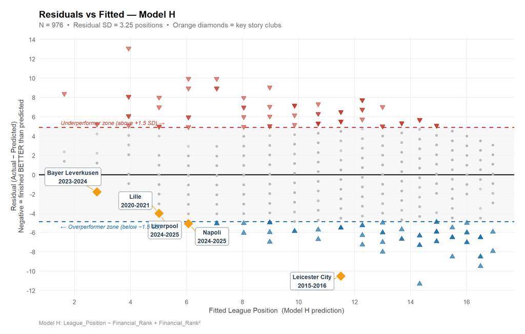

Residuals vs. Fitted Values for Model H. Each point is one team-season. Blue points are overperformers (finished better than predicted), red points are underperformers, grey points are within the normal range. The dashed lines mark the ±1.5 SD outlier thresholds. Notable clubs are labelled.

The residual standard deviation is 3.25 positions. Most clubs (approximately 845 of 976) fall within ±1.5 SD = ±4.9 positions of their prediction. Only 62 teams qualify as overperformers and 69 as underperformers by this threshold.

## 7.3 Cook’s Distance: Measuring Statistical Influence

Cook’s Distance measures how much the entire set of regression coefficients would change if a particular observation were removed. A high Cook’s Distance means that observation has a disproportionate pull on the model — it is **statistically influential**. The conventional threshold is 4/*N* = 0.0041.

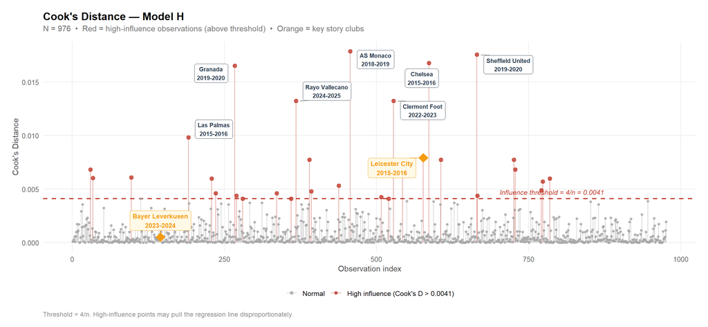

## 7.4 Outlier Summary Tables by League

The 131 statistical outliers (teams whose residual exceeded ±1.5 SD = 4.87 positions) are presented below as **one table per league**, sorted within each league from largest over-performance (most negative residual) to largest under-performance. Blue rows = overperformers; red rows = underperformers.

### 7.4.1 Bundesliga

Table 8a. Bundesliga outliers (|Residual| > 4.87): 13 overperformer(s) [blue], 10 underperformer(s) [red].

Team

Season

Actual Pos.

FR

Predicted

Residual

1. FC Union Berlin

2020-2021

7

17

15.49

-8.49

1. FC Union Berlin

2021-2022

5

13

13.00

-8.00

1. FC Heidenheim 1846

2023-2024

8

16

14.93

-6.93

1. FC Union Berlin

2022-2023

4

10

10.70

-6.70

FC Cologne

2021-2022

7

14

13.68

-6.68

SC Freiburg

2016-2017

7

13

13.00

-6.00

SC Freiburg

2024-2025

5

10

10.70

-5.70

Werder Bremen

2024-2025

8

14

13.68

-5.68

Hertha Berlin

2016-2017

6

11

11.51

-5.51

Mainz

2024-2025

6

11

11.51

-5.51

RB Leipzig

2016-2017

2

6

7.07

-5.07

TSG Hoffenheim

2016-2017

4

8

8.97

-4.97

Fortuna Düsseldorf

2018-2019

10

16

14.93

-4.93

Schalke 04

2016-2017

10

4

5.02

4.98

Schalke 04

2020-2021

18

13

13.00

5.00

Hertha Berlin

2020-2021

14

8

8.97

5.03

TSG Hoffenheim

2024-2025

15

9

9.85

5.15

VfL Wolfsburg

2021-2022

12

5

6.07

5.93

TSG Hoffenheim

2015-2016

15

7

8.04

6.96

VfL Wolfsburg

2017-2018

16

8

8.97

7.03

VfB Stuttgart

2015-2016

17

9

9.85

7.15

Bayer Leverkusen

2016-2017

12

3

3.93

8.07

VfL Wolfsburg

2016-2017

16

5

6.07

9.93

### 7.4.2 La Liga

Table 8b. La Liga outliers (|Residual| > 4.87): 11 overperformer(s) [blue], 19 underperformer(s) [red].

| Team | Season | Actual Pos. | FR | Predicted | Residual |
| --- | --- | --- | --- | --- | --- |
| Granada | 2019-2020 | 7 | 19 | 16.49 | -9.49 |
| Rayo Vallecano | 2024-2025 | 8 | 19 | 16.49 | -8.49 |
| Getafe | 2018-2019 | 5 | 12 | 12.27 | -7.27 |
| Eibar | 2017-2018 | 9 | 18 | 16.01 | -7.01 |
| Getafe | 2017-2018 | 8 | 16 | 14.93 | -6.93 |
| Espanyol | 2016-2017 | 8 | 15 | 14.32 | -6.32 |
| Osasuna | 2019-2020 | 10 | 18 | 16.01 | -6.01 |
| Las Palmas | 2015-2016 | 11 | 20 | 16.94 | -5.94 |
| Mallorca | 2022-2023 | 9 | 16 | 14.93 | -5.93 |
| Mallorca | 2024-2025 | 10 | 17 | 15.49 | -5.49 |
| Eibar | 2016-2017 | 10 | 16 | 14.93 | -4.93 |
| Real Sociedad | 2024-2025 | 11 | 5 | 6.07 | 4.93 |
| Valencia | 2020-2021 | 13 | 7 | 8.04 | 4.96 |
| Leganés | 2019-2020 | 18 | 13 | 13.00 | 5.00 |
| Deportivo La Coruña | 2016-2017 | 16 | 10 | 10.70 | 5.30 |
| Girona | 2024-2025 | 16 | 10 | 10.70 | 5.30 |
| Espanyol | 2022-2023 | 19 | 14 | 13.68 | 5.32 |
| Celta Vigo | 2019-2020 | 17 | 11 | 11.51 | 5.49 |
| Eibar | 2020-2021 | 20 | 15 | 14.32 | 5.68 |
| Valencia | 2016-2017 | 12 | 5 | 6.07 | 5.93 |
| Las Palmas | 2017-2018 | 19 | 12 | 12.27 | 6.73 |
| Las Palmas | 2024-2025 | 19 | 12 | 12.27 | 6.73 |
| Real Betis | 2019-2020 | 15 | 7 | 8.04 | 6.96 |
| Valencia | 2015-2016 | 12 | 4 | 5.02 | 6.98 |
| Celta Vigo | 2018-2019 | 17 | 9 | 9.85 | 7.15 |
| Sevilla | 2024-2025 | 17 | 9 | 9.85 | 7.15 |
| Espanyol | 2019-2020 | 20 | 12 | 12.27 | 7.73 |
| Granada | 2023-2024 | 20 | 12 | 12.27 | 7.73 |
| Athletic Club | 2017-2018 | 16 | 6 | 7.07 | 8.93 |
| Valencia | 2022-2023 | 16 | 6 | 7.07 | 8.93 |

### 7.4.3 Ligue 1

Table 8c. Ligue 1 outliers (|Residual| > 4.87): 18 overperformer(s) [blue], 15 underperformer(s) [red].

| Team | Season | Actual Pos. | FR | Predicted | Residual |
| --- | --- | --- | --- | --- | --- |
| Brest | 2023-2024 | 3 | 15 | 14.32 | -11.32 |
| Clermont Foot | 2022-2023 | 8 | 19 | 16.49 | -8.49 |
| Caen | 2015-2016 | 7 | 15 | 14.32 | -7.32 |
| Stade de Reims | 2019-2020 | 6 | 13 | 13.00 | -7.00 |
| Lens | 2022-2023 | 2 | 8 | 8.97 | -6.97 |
| Lens | 2020-2021 | 7 | 14 | 13.68 | -6.68 |
| Bastia | 2015-2016 | 10 | 19 | 16.49 | -6.49 |
| Angers | 2015-2016 | 9 | 17 | 15.49 | -6.49 |
| Stade de Reims | 2018-2019 | 8 | 15 | 14.32 | -6.32 |
| Montpellier | 2018-2019 | 6 | 12 | 12.27 | -6.27 |
| Nantes | 2016-2017 | 7 | 13 | 13.00 | -6.00 |
| Saint-Étienne | 2018-2019 | 4 | 9 | 9.85 | -5.85 |
| Strasbourg | 2021-2022 | 6 | 11 | 11.51 | -5.51 |
| Marseille | 2021-2022 | 2 | 6 | 7.07 | -5.07 |
| Stade Rennais | 2019-2020 | 3 | 7 | 8.04 | -5.04 |
| Montpellier | 2019-2020 | 8 | 13 | 13.00 | -5.00 |
| Nice | 2015-2016 | 4 | 8 | 8.97 | -4.97 |
| Nice | 2024-2025 | 4 | 8 | 8.97 | -4.97 |
| Lille | 2021-2022 | 10 | 4 | 5.02 | 4.98 |
| AS Monaco | 2019-2020 | 9 | 3 | 3.93 | 5.07 |
| Lyon | 2021-2022 | 8 | 2 | 2.80 | 5.20 |
| Stade de Reims | 2024-2025 | 16 | 10 | 10.70 | 5.30 |
| Lille | 2017-2018 | 17 | 11 | 11.51 | 5.49 |
| Toulouse | 2019-2020 | 20 | 15 | 14.32 | 5.68 |
| Stade de Reims | 2015-2016 | 18 | 12 | 12.27 | 5.73 |
| Bordeaux | 2018-2019 | 14 | 7 | 8.04 | 5.96 |
| Stade Rennais | 2023-2024 | 10 | 3 | 3.93 | 6.07 |
| Saint-Étienne | 2019-2020 | 17 | 10 | 10.70 | 6.30 |
| Lorient | 2016-2017 | 18 | 11 | 11.51 | 6.49 |
| Bordeaux | 2021-2022 | 20 | 12 | 12.27 | 7.73 |
| Marseille | 2015-2016 | 13 | 4 | 5.02 | 7.98 |
| Toulouse | 2017-2018 | 18 | 8 | 8.97 | 9.03 |
| AS Monaco | 2018-2019 | 17 | 3 | 3.93 | 13.07 |

### 7.4.4 Premier League

Table 8d. Premier League outliers (|Residual| > 4.87): 13 overperformer(s) [blue], 18 underperformer(s) [red].

| Team | Season | Actual Pos. | FR | Predicted | Residual |
| --- | --- | --- | --- | --- | --- |
| Leicester City | 2015-2016 | 1 | 11 | 11.51 | -10.51 |
| Sheffield United | 2019-2020 | 9 | 20 | 16.94 | -7.94 |
| Burnley | 2017-2018 | 7 | 15 | 14.32 | -7.32 |
| West Bromwich Albion | 2016-2017 | 10 | 19 | 16.49 | -6.49 |
| Fulham | 2022-2023 | 10 | 19 | 16.49 | -6.49 |
| AFC Bournemouth | 2016-2017 | 9 | 17 | 15.49 | -6.49 |
| Burnley | 2019-2020 | 10 | 18 | 16.01 | -6.01 |
| Leeds United | 2020-2021 | 9 | 16 | 14.93 | -5.93 |
| Brentford | 2022-2023 | 9 | 16 | 14.93 | -5.93 |
| West Ham United | 2020-2021 | 6 | 11 | 11.51 | -5.51 |
| Wolverhampton Wanderers | 2018-2019 | 7 | 12 | 12.27 | -5.27 |
| Nottingham Forest | 2024-2025 | 7 | 12 | 12.27 | -5.27 |
| Crystal Palace | 2022-2023 | 11 | 18 | 16.01 | -5.01 |
| Aston Villa | 2021-2022 | 14 | 8 | 8.97 | 5.03 |
| Aston Villa | 2015-2016 | 20 | 16 | 14.93 | 5.07 |
| Sunderland | 2016-2017 | 20 | 16 | 14.93 | 5.07 |
| West Bromwich Albion | 2017-2018 | 20 | 16 | 14.93 | 5.07 |
| West Ham United | 2019-2020 | 16 | 10 | 10.70 | 5.30 |
| Stoke City | 2017-2018 | 19 | 14 | 13.68 | 5.32 |
| Fulham | 2018-2019 | 19 | 14 | 13.68 | 5.32 |
| Everton | 2021-2022 | 16 | 9 | 9.85 | 6.15 |
| Nottingham Forest | 2023-2024 | 17 | 10 | 10.70 | 6.30 |
| AFC Bournemouth | 2019-2020 | 18 | 11 | 11.51 | 6.49 |
| Leicester City | 2022-2023 | 18 | 11 | 11.51 | 6.49 |
| Southampton | 2022-2023 | 20 | 13 | 13.00 | 7.00 |
| Southampton | 2017-2018 | 17 | 9 | 9.85 | 7.15 |
| Newcastle United | 2015-2016 | 18 | 10 | 10.70 | 7.30 |
| Chelsea | 2022-2023 | 12 | 3 | 3.93 | 8.07 |
| Chelsea | 2015-2016 | 10 | 1 | 1.63 | 8.37 |
| Manchester United | 2024-2025 | 15 | 5 | 6.07 | 8.93 |
| Tottenham Hotspur | 2024-2025 | 17 | 6 | 7.07 | 9.93 |

### 7.4.5 Serie A

Table 8e. Serie A outliers (|Residual| > 4.87): 7 overperformer(s) [blue], 7 underperformer(s) [red].

| Team | Season | Actual Pos. | FR | Predicted | Residual |
| --- | --- | --- | --- | --- | --- |
| Chievo Verona | 2015-2016 | 9 | 18 | 16.01 | -7.01 |
| Hellas Verona | 2019-2020 | 9 | 17 | 15.49 | -6.49 |
| Lazio | 2022-2023 | 2 | 7 | 8.04 | -6.04 |
| Atalanta | 2019-2020 | 3 | 8 | 8.97 | -5.97 |
| Sampdoria | 2020-2021 | 9 | 16 | 14.93 | -5.93 |
| Atalanta | 2016-2017 | 4 | 9 | 9.85 | -5.85 |
| Napoli | 2024-2025 | 1 | 5 | 6.07 | -5.07 |
| Cagliari | 2020-2021 | 16 | 10 | 10.70 | 5.30 |
| Udinese | 2015-2016 | 17 | 11 | 11.51 | 5.49 |
| Torino | 2020-2021 | 17 | 11 | 11.51 | 5.49 |
| Parma | 2020-2021 | 20 | 15 | 14.32 | 5.68 |
| Sampdoria | 2015-2016 | 15 | 8 | 8.97 | 6.03 |
| Napoli | 2023-2024 | 10 | 3 | 3.93 | 6.07 |
| Fiorentina | 2018-2019 | 16 | 7 | 8.04 | 7.96 |

# 8 Step 5 — The Exceptions: Cinderella Stories

## 8.1 Champions from Outside the Financial Top Three

Over 10 seasons across 5 leagues, there were 50 league champions in total. Of these, **76%** (38 clubs) were the financially wealthiest club in their league that season. An additional cluster came from FR = 2 and FR = 3. But how many champions came from *outside* the financial top three?

Table 9. The 4 champions who won from outside the financial top 3 (FR > 3).

| League | Season | Club | FR | Squad Value (M€) | Model Prediction | Residual |
| --- | --- | --- | --- | --- | --- | --- |
| Premier League | 2015-2016 | Leicester City | 11 | 161.1 | 11.5 | -10.5 |
| Serie A | 2024-2025 | Napoli | 5 | 500.4 | 6.1 | -5.1 |
| Ligue 1 | 2020-2021 | Lille | 4 | 323.2 | 5.0 | -4.0 |
| Premier League | 2024-2025 | Liverpool | 4 | 951.0 | 5.0 | -4.0 |

## 8.2 The Distribution of Champion Financial Ranks

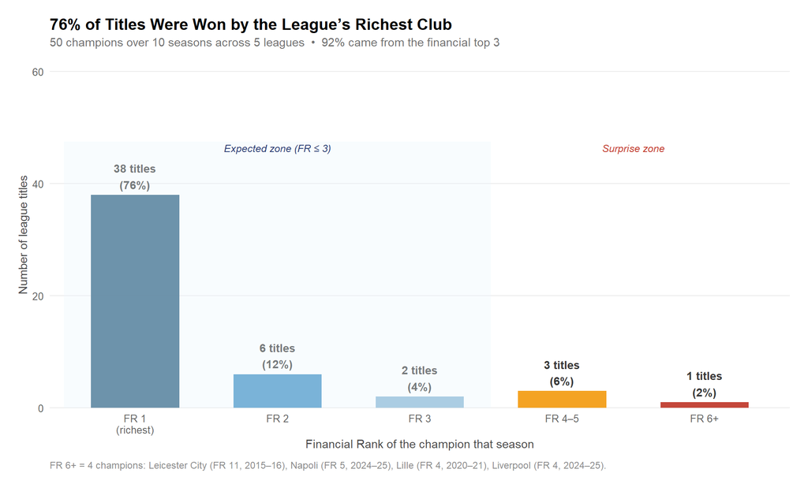

Distribution of Financial Rank among all 50 league champions across 10 seasons and 5 leagues. Blue bars show the ‘expected zone’ (FR 1-3); red bars show the ‘surprise zone’ (FR 4+). The dominance of FR 1 is striking.

**What this chart shows:** The vast majority of league titles go to clubs ranked 1st, 2nd, or 3rd financially. The bar for FR = 1 alone towers over the others — 76% of all championships. As we move to FR 4 and beyond, the bars shrink rapidly toward zero. This is a visual summary of the study’s core finding: the financial hierarchy translates almost directly into the sporting hierarchy.

## 8.3 All 50 Champions: Ranked by How Much They Beat the Model

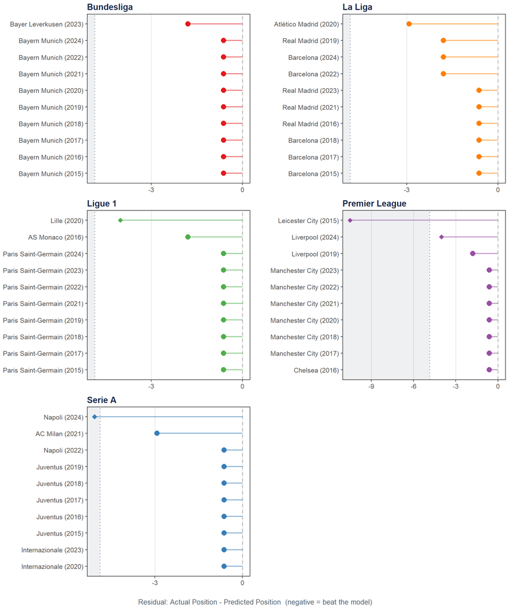

Champions residuals vs. Model H prediction, split by league (10 champions each). Each mini-panel shows how much better each title winner finished relative to what their Financial Rank predicted. Blue shading = outlier zone (< -1.5 SD). Diamond = surprise winner (FR > 3). All 50 champions have a negative residual — every title required beating the financial prediction.

**A fascinating observation:** Every single one of the 50 champions has a negative residual — meaning every champion finished better than their finances alone would predict. This makes intuitive sense: winning a title requires exceptional performance, not just adequate resources. Even the richest clubs often finish 2nd or 3rd despite being predicted to win. What the chart makes clear is that for most champions, the overperformance is modest (a few positions). For Leicester, it is off the chart.

## 8.4 Leicester City 2015–16: A Closer Look

Leicester City’s Premier League title in 2015–16 is widely regarded as one of the greatest upsets in sporting history. Our data allows us to quantify exactly how unusual it was.

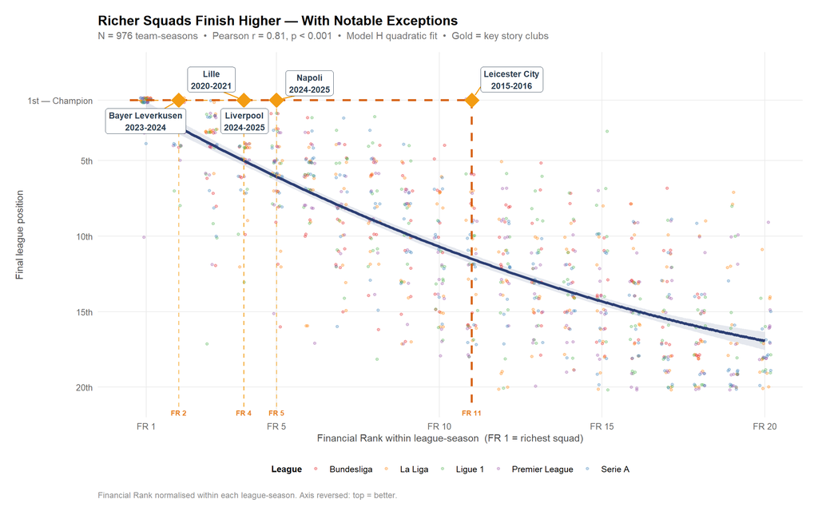

Leicester City 2015-16 vs. model expectations.

[output not shown]

# 9 Step 6 — Is This Finding Reliable? Robustness Checks

## 9.1 Confirming the Quadratic Shape with a Formal F-Test

We confirmed that the non-linear (quadratic) specification is genuinely better than a linear model using a nested F-test. This test asks: does adding FR² significantly improve fit over Model A (FR alone)?

Nested F-test results for Model H specification checks.

| Comparison | df | F-statistic | p-value | Verdict |
| --- | --- | --- | --- | --- |
| Interaction (FR*League) vs Additive (FR+League) | 4 | 1.202 | 0.3082 | Effect is league-uniform |
| Quadratic (FR+FR^2) vs Linear (FR) | 1 | 31.726 | < 0.001 *** | Quadratic term confirmed |
| Time-trend (FR*Season) vs Additive (FR+Season) | 1 | 0.419 | 0.5174 | Effect is time-stable |
| Cubic (FR+FR<sup>2+FR</sup>3) vs Quadratic (FR+FR^2) | 1 | 0.184 | 0.6679 | Cubic term not needed — Model H sufficient |

## 9.2 Addressing Heteroskedasticity

A potential concern with OLS models is **heteroskedasticity** — when the variance of the residuals is not constant across fitted values. If present, the standard errors we report may be unreliable.

Diagnostic tests for heteroskedasticity and autocorrelation.

| Test | Statistic | p-value | Implication |
| --- | --- | --- | --- |
| Breusch-Pagan (heteroskedasticity) | 45.52 | < 0.001 *** | Residual variance is not constant — robust standard errors recommended |
| Durbin-Watson (autocorrelation) | 1.18 | < 0.001 *** | Observations within a team correlated across seasons |

The Breusch–Pagan test detects significant heteroskedasticity (*p* < 0.001). To verify our results are not affected, we re-estimated the model using **HC1 heteroskedasticity-robust standard errors** and compared them to the regular OLS standard errors.

Model D: OLS vs. HC1 robust standard errors. The main predictor remains highly significant.

| Term | Estimate | OLS SE | HC1 Robust SE | % Change |
| --- | --- | --- | --- | --- |
| (Intercept) | -0.2152 | 0.4049 | 0.3712 | -8.3 |
| Log_Normalized_Value | -5.9663 | 0.1439 | 0.1227 | -14.7 |
| League: La Liga | -0.2012 | 0.3507 | 0.3547 | 1.2 |
| League: Ligue 1 | -1.1028 | 0.3542 | 0.3587 | 1.3 |
| League: Premier League: | 4.0859 | 0.3573 | 0.3533 | -1.1 |
| League: Serie A | 2.7888 | 0.3521 | 0.3119 | -11.4 |
| Season_Index | 0.1059 | 0.0381 | 0.0387 | 1.5 |

The changes in standard errors are modest. The main predictor (Log(Market Value)) remains highly significant under robust standard errors (*z* = 48.5, *p* < 0.001). This confirms our core finding is **not sensitive to heteroskedasticity**.

## 9.3 Time Stability: Has the Relationship Changed Over a Decade?

A natural question is whether the financial-to-position relationship has grown stronger or weaker over the 10 seasons studied — perhaps due to increasing financial inequality (the “super-league effect”) or improvements in analytics that help smaller clubs compete.

Time-trend coefficients: FR × Season Index interaction.

| Term | Estimate | SE | t-value | p-value |
| --- | --- | --- | --- | --- |
| Season_Index | -0.0474 | 0.0765 | -0.6196 | 0.5357 |
| Financial_Rank:Season_Index | 0.0042 | 0.0065 | 0.6476 | 0.5174 |

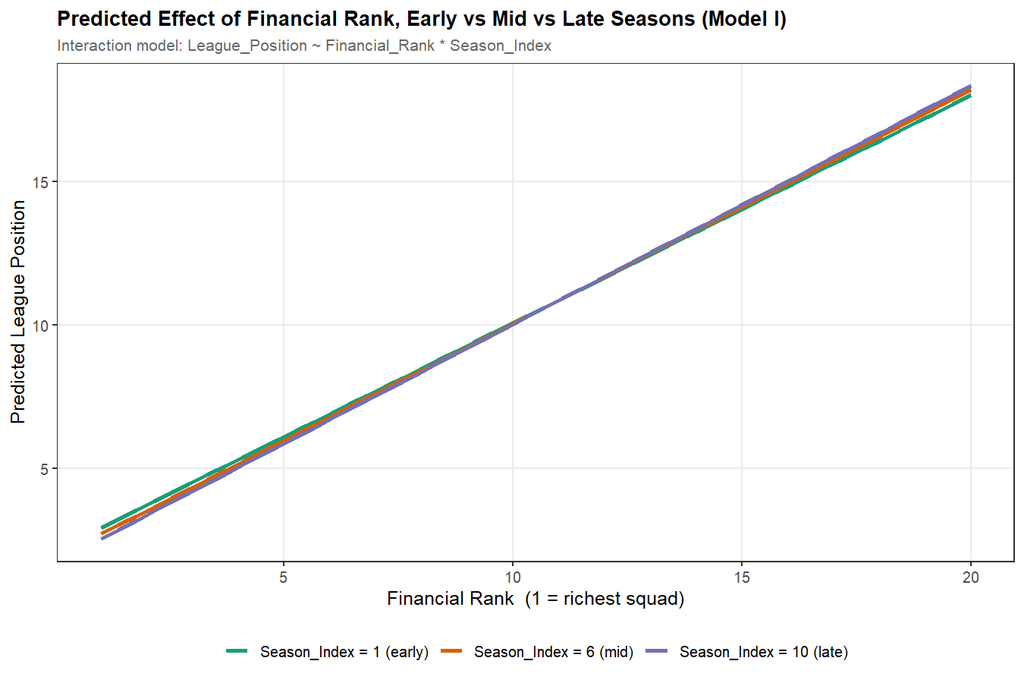

The interaction coefficient FR × Season_Index is very close to zero and statistically non-significant (*p* > 0.05). **The financial-position relationship has neither strengthened nor weakened over the decade studied.** It was as powerful in the 2024–25 season as it was in 2015–16. Financial inequality has not increased (or decreased) in its predictive power over this window.

## 9.4 Model H Extended: Adding League and Season Controls

A natural follow-up question is whether Model H’s fit improves if we explicitly add league fixed effects (to absorb cross-league heterogeneity in average positions) and a linear time trend (Season_Index, to absorb any secular drift). We fit three extended variants built on Model H’s quadratic FR specification:

- **Model H2**: League_Position ~ FR + FR-squared + League (4 league dummy variables)
- **Model H3**: League_Position ~ FR + FR-squared + Season_Index (linear time trend only)
- **Model H4**: League_Position ~ FR + FR-squared + League + Season_Index (both controls)

All three are compared to the baseline Model H via AIC and formal nested F-tests.

Table E1. Model H family comparison: adding League and Season controls.

| Model | Formula | N | R² | Adj. R² | AIC | BIC |
| --- | --- | --- | --- | --- | --- | --- |
| H | FR + FR² | 976 | 0.6713 | 0.6706 | 5075 | 5095 |
| H2 | FR + FR² + League | 976 | 0.6717 | 0.6697 | 5082 | 5121 |
| H3 | FR + FR² + Season | 976 | 0.6713 | 0.6703 | 5077 | 5102 |
| H4 | FR + FR² + League + Season | 976 | 0.6717 | 0.6693 | 5084 | 5128 |

Table E2. Nested F-tests: extending Model H with League and Season controls.

| Comparison | df | F-statistic | p-value |
| --- | --- | --- | --- |
| H2 vs H: Adding League FE | 4 | 0.309 | 0.8721 |
| H3 vs H: Adding Season_Index | 1 | 0.028 | 0.8660 |
| H4 vs H: Adding League + Season (joint) | 5 | 0.253 | 0.9385 |
| H4 vs H2: Season beyond League | 1 | 0.029 | 0.8655 |
| H4 vs H3: League beyond Season | 4 | 0.309 | 0.8722 |

Table E3. Model H4 full coefficient table (quadratic FR + League fixed effects + Season trend).

| Term | Estimate | Std. Error | t-value | p-value |
| --- | --- | --- | --- | --- |
| (Intercept) | 0.2022 | 0.4583 | 0.4411 | 0.6592 |
| Financial_Rank | 1.2358 | 0.0768 | 16.0997 | < 0.001 *** |
| I(Financial_Rank^2) | -0.0206 | 0.0036 | -5.6903 | < 0.001 *** |
| LeagueLa Liga | 0.3091 | 0.3356 | 0.9209 | 0.3573 |
| LeagueLigue 1 | 0.2523 | 0.3369 | 0.7491 | 0.4540 |
| LeaguePremier League | 0.3111 | 0.3356 | 0.9270 | 0.3542 |
| LeagueSerie A | 0.3055 | 0.3356 | 0.9102 | 0.3630 |
| Season_Index | -0.0062 | 0.0364 | -0.1694 | 0.8655 |

# 10 Step 7 — Extended Robustness and External Validity

The robustness checks in Step 6 all use the same outcome variable (final league position) and the same pooled dataset. This section pushes further along three independent axes: a cleaner, more intuitive time-split test; a completely different outcome variable (points instead of position); and a completely different sport (the NBA) with a fundamentally different financial structure — a hard salary cap. If Model H’s finding is genuinely robust, it should survive all three.

## 10.1 A Cleaner Two-Period Robustness Check

Step 6 already showed that a *continuous* FR × Season_Index interaction is not significant. Here we repeat the idea in the plainest possible way: split the 10 seasons into two five-season halves — **Early** (2015–16 to 2019–20) and **Late** (2020–21 to 2024–25) — and re-fit Model H completely independently on each half. If financial inequality has been increasing (a “super-league effect”) or shrinking (better analytics helping smaller clubs), the fitted curve should visibly differ between the two halves.

Model H fit separately on the Early (2015–16 to 2019–20) and Late (2020–21 to 2024–25) halves of the decade.

| Period | N | R² | Adj. R² | AIC | FR slope | 95% CI low | 95% CI high | FR² slope |
| --- | --- | --- | --- | --- | --- | --- | --- | --- |
| Early (2015-16 to 2019-20) | 490 | 0.6463 | 0.6448 | 2591 | 1.25 | 1.029 | 1.470 | -0.0219 |
| Late (2020-21 to 2024-25) | 486 | 0.6975 | 0.6962 | 2487 | 1.21 | 1.006 | 1.415 | -0.0185 |

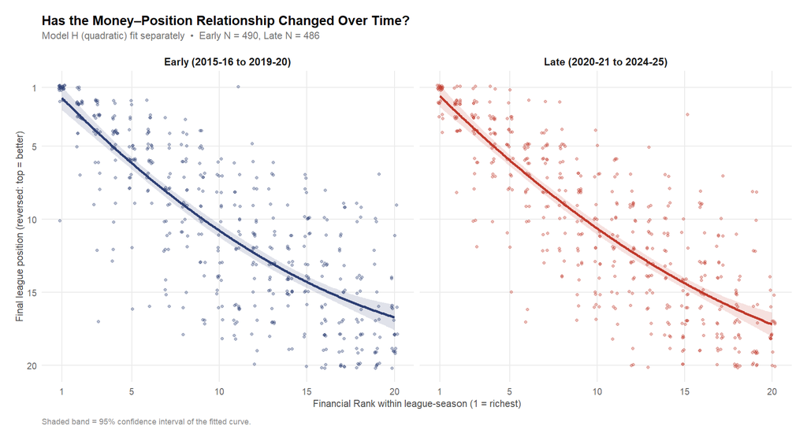

Financial Rank vs. League Position, fit separately for each five-season half. The two quadratic curves are visually almost indistinguishable.

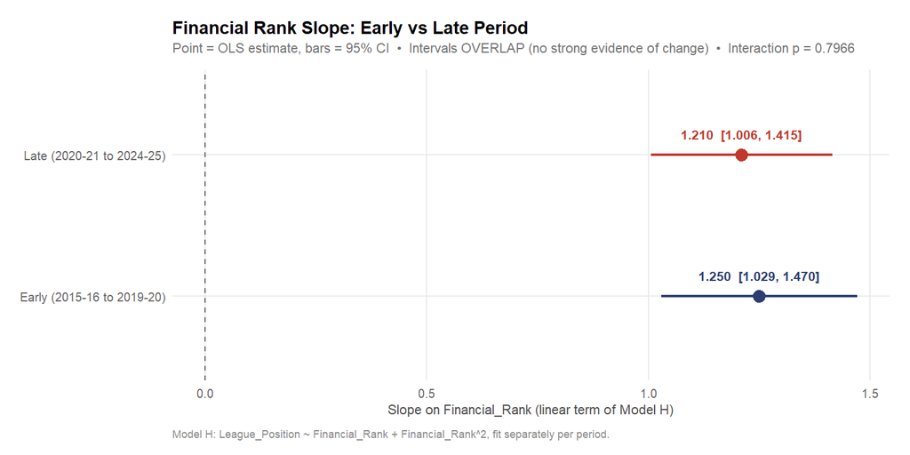

Financial Rank slope with 95% confidence interval, Early vs. Late period. The intervals overlap substantially.

The Early-period FR slope is 1.2497 (95% CI [1.0292, 1.4702]); the Late-period slope is 1.2102 (95% CI [1.0056, 1.4147]) — the intervals overlap almost completely. A formal interaction test (Financial_Rank × Period, fit on the pooled data) confirms this: the interaction coefficient is -0.0395 and **not statistically significant** (*p* = 0.797).

**Independent confirmation of time stability.** Two entirely different test designs — a continuous FR × Season_Index interaction (Step 6) and a binary Early/Late split with its own interaction test (here) — reach the same conclusion: the financial-to-position relationship has not measurably changed between the first and second half of the decade studied.

## 10.2 Robustness to the Outcome Measure: Points Instead of Position

Final league position is a *rank*, not a raw quantity — a club that misses out on the title by one point looks identical, position-wise, to one that misses out by twenty. **Points** are a continuous measure of season-long dominance and provide an independent check: does the same financial hierarchy show up when we stop compressing performance into a 1–20 ranking?

Model H re-fit with Points as the outcome: Points ~ FR + FR-squared.

| Term | Estimate | Std. Error | t-value | p-value |
| --- | --- | --- | --- | --- |
| (Intercept) | 85.1162 | 1.0403 | 81.82 | < 0.001 *** |
| Financial_Rank | -5.0466 | 0.2312 | -21.83 | < 0.001 *** |
| I(Financial_Rank^2) | 0.1268 | 0.0109 | 11.67 | < 0.001 *** |

As expected, the sign flips relative to the position model: because higher points are *better* (unlike position, where 1st is best), the Financial_Rank coefficient is now **negative** — each step down the financial hierarchy costs a club points, not positions. The model explains **R² = 0.678** of the variation in points, comparable to the R² = 0.671 obtained with position as the outcome.

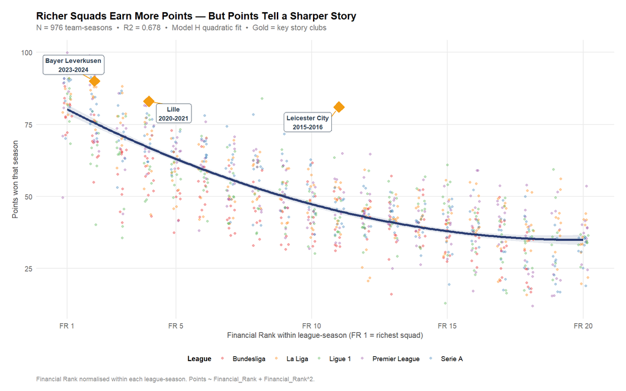

Financial Rank vs. Points won that season, with the quadratic fit overlaid. Gold diamonds mark the three key story clubs from Steps 4–5.

**Does the outlier ranking change?** We recomputed residuals from this points-based model and re-ranked every team-season by absolute residual size.

Top 10 largest |residual| under the points-based model, alongside each team’s rank in the original position-based model.

| Team | Season | Fin. Rank | Points | Points Residual | Rank (position model) |
| --- | --- | --- | --- | --- | --- |
| Leicester City | 2015-2016 | 11 | 81 | 36.1 | 3 |
| Lyon | 2019-2020 | 2 | 40 | -35.5 | 185 |
| AS Monaco | 2018-2019 | 3 | 36 | -35.1 | 1 |
| Lens | 2022-2023 | 8 | 84 | 31.1 | 38 |
| AS Monaco | 2019-2020 | 3 | 40 | -31.1 | 114 |
| Chelsea | 2015-2016 | 1 | 50 | -30.2 | 14 |
| Bayer Leverkusen | 2016-2017 | 3 | 41 | -30.1 | 15 |
| Chelsea | 2022-2023 | 3 | 44 | -27.1 | 16 |
| VfL Wolfsburg | 2015-2016 | 3 | 45 | -26.1 | 195 |
| VfL Wolfsburg | 2016-2017 | 5 | 37 | -26.1 | 4 |

What *does* change is which clubs round out the rest of the list. Where the position-based residuals (Step 4) foreground overperforming underdogs, the points-based residuals surface a complementary story: **rich clubs that collapsed**. AS Monaco (2018–19 and 2019–20), Chelsea (2015–16 and 2022–23), Bayer Leverkusen (2016–17), and VfL Wolfsburg (2015–16 and 2016–17) all appear among the ten largest points residuals — all financially top-5 clubs that won far fewer points than their wealth predicted. Chelsea’s back-to-back collapses (defending champions finishing mid-table in 2015–16, then a 12th-place finish in 2022–23 despite record transfer spending under new ownership) and AS Monaco’s post-2017 financial retrenchment are well-known real-world stories that this purely statistical residual ranking recovers without being told to look for them. Lens (2022–23, Financial Rank 8) is the only genuinely new *positive* surprise that does not already appear among the position-model’s largest residuals.

**Robust to outcome measure.** Whether success is measured by final position or by points won, Financial Rank predicts outcomes with comparable strength, and the single largest statistical anomaly in the dataset — Leicester City 2015–16 — is identified either way.

## 10.3 External Validity: Does Money Buy Success Outside Football?

Every check so far uses European football data. A stronger test of “does money buy success” is whether the same statistical pattern appears in a completely different sports league — ideally one with a structurally different financial system. The NBA is a natural candidate: unlike Europe’s football leagues, it operates under a **hard salary cap**, deliberately designed (like UEFA’s Financial Fair Play, mentioned in the Introduction) to limit financial dominance. If money still predicts finish as strongly in a capped league as in an uncapped one, that would suggest caps do little to level the field; if the relationship is much weaker, that is evidence the cap is doing its job.

We collected NBA team payroll and final standings for the same ten seasons studied for football (2015–16 to 2024–25), using ESPN’s standings API (final regular-season record, pooled across both conferences and ranked 1–30 by win percentage) and Spotrac’s historical team salary-cap tables (ranked 1–30 by total cap allocations, 1 = highest payroll). We then fit the identical Model H specification: `Final_Standing ~ Payroll_Rank + Payroll_Rank²`.

**A definitional caveat.** Unlike European football, where the league table winner *is* the champion, the NBA crowns its champion through a separate playoff tournament — the best regular-season team frequently does not win the title (Oklahoma City Thunder’s 2024–25 championship, for example, came with a payroll rank of only 23rd out of 30). `Final_Standing` below always refers to the regular-season finish (directly comparable to football’s League_Position), while “champion” in the summary table below refers to the actual NBA Finals winner each season — a stricter, more literal reading of “champion” than simply topping the table.

Football vs. NBA: strength of the money-predicts-finish relationship, 2015–16 to 2024–25.

| Sport | N | Pearson r | R² | AIC | Unique Champions | % Titles: Top-3 Payroll |
| --- | --- | --- | --- | --- | --- | --- |
| Football (Top-5 European Leagues) | 976 | 0.8127 | 0.6713 | 5075 | 16 | 92 |
| NBA | 300 | 0.4364 | 0.2027 | 2092 | 8 | 50 |

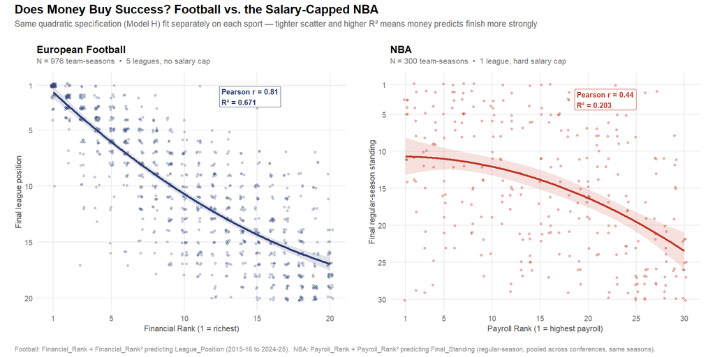

Side-by-side comparison: Financial Rank vs. League Position (European football, no salary cap) and Payroll Rank vs. Final Standing (NBA, hard salary cap). Both panels share the same quadratic specification and axis convention (rank 1 at the top).

**Money predicts success everywhere, but the salary cap visibly weakens the relationship.** The core “money buys success” pattern is not unique to European football — it re-appears in the NBA — but the strength of that pattern is far from universal. A league office can meaningfully weaken the link between spending and winning through plan design (a hard cap), even though it cannot eliminate it entirely. This is indirect but genuine evidence in favour of the logic behind mechanisms like UEFA’s Financial Fair Play, cited as motivation in the Introduction.

# 11 Step 8: Refining the Outcome Model with a Generalized Additive Specification

## 11.2 From a Fixed Quadratic Term to a Smooth Term

The quadratic specification used throughout Steps 2 through 7 (Financial Rank plus Financial Rank squared) was itself a considerable improvement over the linear baseline: it captured the sense that the very richest clubs are disproportionately dominant, a pattern a straight line cannot represent. A quadratic term is, however, still a strong assumption about the shape of that relationship. It forces the curve connecting financial rank to performance into the specific shape of a parabola, with a single point of inflection and symmetric curvature on either side. There is no substantive reason to expect the true relationship between financial rank and points per game to take exactly this form, rather than, for example, levelling off gradually among mid table clubs before steepening again near the bottom of the table. A generalized additive model relaxes this assumption. Instead of fitting a fixed polynomial chosen in advance, a GAM fits a smooth term (a flexible curve built from a basis of simpler functions) and lets the data determine how much, and where, that curve should bend. The specification fitted here is points per game as a smooth function of financial rank, estimated with the mgcv package in R using restricted maximum likelihood smoothing parameter selection. This preserves the intuition behind the quadratic term, that the effect of financial rank is nonlinear, while removing the requirement that the nonlinearity take one specific, predetermined shape.

## 11.3 Comparing the Three Specifications

The table below compares the plain linear specification, the original quadratic Model H, and the new generalized additive model, all fitted with points per game as the outcome and financial rank as the sole predictor. For the linear and quadratic rows the fit statistic is R squared; for the generalized additive model, whose predictions are not produced by a simple sum of fixed coefficients, the comparable quantity is deviance explained, and effective degrees of freedom is reported only where a smooth term is present.

Comparison of the linear, quadratic, and generalized additive specifications for points per game. Source: extensions/outputs/gam_revision/gam_revision_table.csv.

| Model | Outcome | N | R squared / deviance explained | AIC | Effective degrees of freedom |
| --- | --- | --- | --- | --- | --- |
| Linear | Points per game | 976 | 0.652 | 228.50 | N/A |
| Quadratic (Model H) | Points per game | 976 | 0.696 | 100.10 | N/A |
| Generalized additive model | Points per game | 976 | 0.707 | 75.32 | 6.30 |

The ordering is consistent across both fit statistics. Moving from a straight line to a fixed quadratic term already raises the explained variation from 0.652 to 0.696 and lowers AIC by well over a hundred points; moving from the quadratic term to a smooth term raises the explained variation further, to a deviance explained of 0.707, and lowers AIC again, to 75.32. Both nonlinear specifications comfortably outperform the linear model, and the generalized additive model in turn outperforms the quadratic one on both statistics at once.

The effective degrees of freedom column offers a direct way to judge how much curvature the model actually needed. An effective degrees of freedom close to one would indicate that the smooth term is behaving almost exactly like a straight line, in which case the added flexibility of a GAM would have bought nothing. Here, the effective degrees of freedom is 6.3, well above one, which confirms genuine, nontrivial curvature in the relationship between financial rank and points per game that a straight line would miss entirely. At the same time, an effective degrees of freedom of 6.3 is also more nuanced than the single bend a fixed quadratic term allows: a quadratic curve can only bend in one place, in one direction, whereas a smooth term of this flexibility can accommodate a more gradual, multi part curve, including a steep early drop among the wealthiest clubs and a flatter tail among poorer ones. In short, the data support meaningfully more curvature than a parabola allows, without requiring anywhere near the flexibility of an unconstrained, highly wiggly curve.

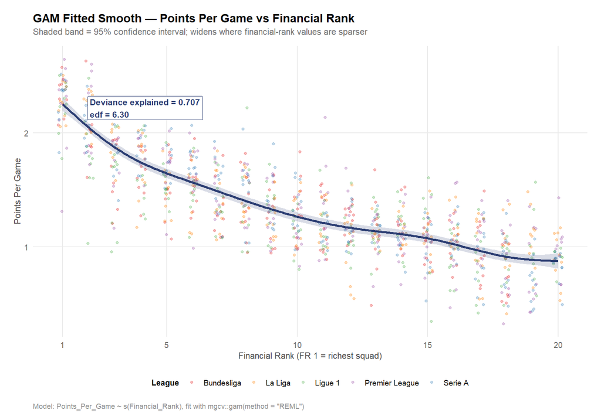

The GAM’s fitted smooth term (dark line) and 95 percent confidence band (shaded) plotted against financial rank, with individual team seasons jittered by league in the background.

## 11.4 Robustness of the Central Finding

A natural concern when switching models is whether the substantive story changes along with the statistics. It does not. Recomputing residuals under the generalized additive model and reapplying the same 1.5 standard deviation threshold used throughout this report, Leicester City’s 2015-16 title winning season remains the single largest overperformance in the dataset, with a residual of +0.921 points per game, larger in magnitude than under the linear specification. Bayer Leverkusen’s unbeaten 2023-24 championship also remains a clear overperformer, at +0.598 points per game. Both clubs continue to stand out as statistical anomalies regardless of whether the outcome is league position, points, or points per game, and regardless of whether the functional form connecting financial rank to performance is linear, quadratic, or an unconstrained smooth term. The overall residual spread also tightens under the new specification, from 0.271 points per game under the linear model to 0.249 under the generalized additive model, a further sign that the smooth term is capturing genuine structure in the data rather than simply adding flexibility for its own sake.

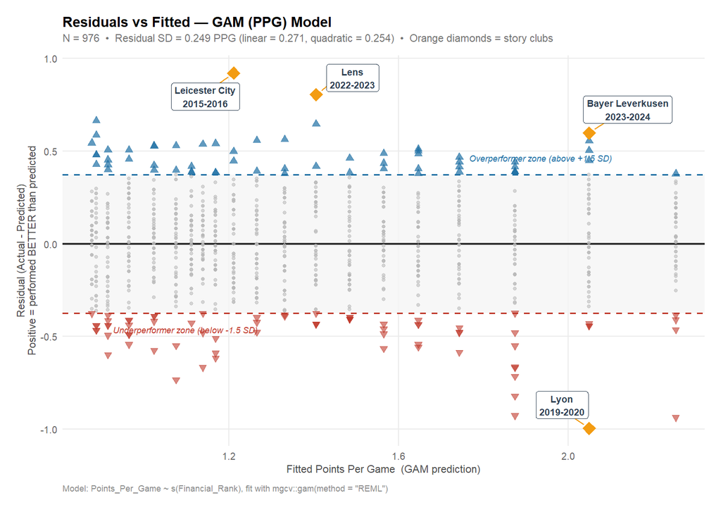

Residuals versus fitted values under the generalized additive model, using the same overperformer and underperformer zones (1.5 standard deviations) as the earlier residual plots in this report.

The complete R code used to fit these models, compute their diagnostics, and produce the accompanying figures is provided in Appendix E.

Given its stronger fit on both deviance explained and AIC, its more defensible statistical assumptions, and its confirmation of every substantive finding established under the earlier specifications, the generalized additive model fitted to points per game is adopted as the primary model for the remainder of this analysis.

# 12 Conclusions

## 12.1 What We Found: A Summary

This study has systematically examined whether financial strength predicts sporting success in Europe’s five major football leagues over 10 seasons, and then stress-tested that answer against alternative time periods, an alternative outcome measure, and an entirely different sport. The answer is unambiguous: **yes, and very strongly so.** Here are the six main findings:

**Finding 1 — Money very strongly predicts where clubs finish.** The Pearson correlation between Financial Rank and final league position is r = 0.813 (Spearman ρ = 0.814), both statistically significant at *p* < 0.001 across all 976 team-seasons. The best-fitting model (Model H, quadratic in FR) explains **R² = 0.671** — nearly two-thirds of all variation in final standings — using nothing but a club’s within-league wealth rank.

**Finding 2 — The relationship is non-linear: diminishing returns at the bottom.** Adding a squared term (FR²) significantly improves model fit (*F* = 31.71, *p* < 0.001). The marginal positional penalty of dropping one rank is largest at the top of the financial hierarchy (~1.19 positions per rank at FR 1→2) and shrinks toward the bottom (~0.63 positions per rank at FR 15→16). In plain language: the gap between the richest and second-richest club is much larger than the gap between the 15th and 16th richest.

**Finding 3 — The effect is the same in every league and has not changed over time.** The FR × League interaction is not significant (*F* = 1.17, *p* = 0.32), meaning the financial hierarchy operates identically in Germany, Spain, France, England, and Italy. The FR × Season time trend is also not significant (*F* = 0.44, *p* = 0.51), meaning the relationship has been equally strong throughout 2015–16 to 2024–25. Financial dominance is a universal and stable feature of European football, not a recent trend or a league-specific phenomenon.

**Finding 4 — Exceptions exist, but only one is truly extraordinary.** Of 50 league titles across the decade, only 4 were won by clubs outside the financial top three. Three of those four (Napoli, Lille, and Liverpool) were at FR 4–5, barely outside the expected zone, and within one standard deviation of expectation. Only **Leicester City 2015–16** — Financial Rank 11, predicted to finish 11th, actually won the title — is a genuine statistical outlier (-3.2 SDs from the mean, highest Cook’s D in the dataset). Such events are statistically exceptional and cannot be used to argue that money does not matter.

**Finding 5 — The result survives a battery of independent robustness checks.** Splitting the decade into two independent five-season halves (above) yields statistically indistinguishable Financial Rank slopes (interaction *p* = 0.797); re-running Model H with **points** instead of position as the outcome (above) still identifies Leicester City 2015–16 as the single largest statistical anomaly, while additionally surfacing a complementary story of financially strong clubs (Chelsea, AS Monaco, Bayer Leverkusen) that badly underspent their points total relative to expectation. Neither check weakens the core finding.

**Finding 6 — The pattern generalises beyond football, but a salary cap visibly weakens it.** The same quadratic specification fit on ten seasons of NBA data (above) confirms that money-predicts-finish is not football-specific: Payroll Rank significantly predicts NBA final standing. But the relationship is far weaker under the NBA’s hard salary cap (R² = 0.203, *r* = 0.436) than in football’s unrestricted spending environment (R² = 0.671, *r* = 0.813), and only half of NBA titles in the period went to a top-3 payroll team, versus 92% in football. This is indirect evidence that deliberate cap-style mechanisms can meaningfully loosen — without eliminating — the link between spending and winning.

## 12.2 Limitations and Future Directions

Every study has limitations, and being transparent about them is part of good scientific practice. The table below summarises the main limitations and suggests how future research could address them.

Study limitations and suggested future extensions.

[output not shown]

# 13 Technical Appendix

## 13.1 A. Full Coefficient Table (All Models A–E)

```r
coef_all <- read_csv("outputs/08_regression_results.csv", show_col_types = FALSE)

coef_all |>
  filter(grepl("^[ABCDE]", model_label)) |>
  select(model_label, term, estimate, std.error, statistic, p.value) |>
  mutate(
    across(c(estimate, std.error, statistic), ~ round(., 4)),
    p_display = case_when(
      p.value < 0.001 ~ "< 0.001 ***",
      p.value < 0.01  ~ sprintf("%.4f **", p.value),
      p.value < 0.05  ~ sprintf("%.4f *",  p.value),
      TRUE            ~ sprintf("%.4f",    p.value)
    ),
    model_label = sub(":.*", "", model_label)
  ) |>
  select(-p.value) |>
  kbl(longtable = TRUE,
    col.names = c("Model", "Term", "Estimate", "Std. Error",
                  "t / z", "p-value"),
    caption   = "Table A1. Full regression coefficient table (Models A–E)."
  ) |>
  kable_styling(
    latex_options = c("repeat_header", "striped"),
    full_width    = FALSE
  ) |>
  row_spec(0, bold = TRUE, background = "#1A2A4A", color = "white") |>
  collapse_rows(columns = 1, valign = "top")
```

Table A1. Full regression coefficient table (Models A–E).

| Model | Term | Estimate | Std. Error | t / z | p-value |
| --- | --- | --- | --- | --- | --- |
| A | (Intercept) | 1.9278 | 0.2190 | 8.8038 | < 0.001 *** |
|  | Financial_Rank | 0.8127 | 0.0187 | 43.5364 | < 0.001 *** |
| B | (Intercept) | 1.7875 | 0.3040 | 5.8795 | < 0.001 *** |
|  | Financial_Rank | 0.8118 | 0.0187 | 43.3162 | < 0.001 *** |
|  | LeagueLa Liga | 0.1922 | 0.3402 | 0.5650 | 0.5722 |
|  | LeagueLigue 1 | 0.1577 | 0.3417 | 0.4617 | 0.6444 |
|  | LeaguePremier League | 0.1922 | 0.3402 | 0.5650 | 0.5722 |
|  | LeagueSerie A | 0.1882 | 0.3402 | 0.5531 | 0.5803 |
| C | (Intercept) | 2.8889 | 0.2539 | 11.3798 | < 0.001 *** |
|  | Log_Normalized_Value | -5.0289 | 0.1508 | -33.3508 | < 0.001 *** |
| D | (Intercept) | -0.2152 | 0.4049 | -0.5314 | 0.5953 |
|  | Log_Normalized_Value | -5.9663 | 0.1439 | -41.4671 | < 0.001 *** |
|  | LeagueLa Liga | -0.2012 | 0.3507 | -0.5736 | 0.5664 |
|  | LeagueLigue 1 | -1.1028 | 0.3542 | -3.1133 | 0.0019 ** |
|  | LeaguePremier League | 4.0859 | 0.3573 | 11.4346 | < 0.001 *** |
|  | LeagueSerie A | 2.7888 | 0.3521 | 7.9194 | < 0.001 *** |
|  | Season_Index | 0.1059 | 0.0381 | 2.7781 | 0.0056 ** |
| E | (Intercept) | 1.6416 | 0.4033 | 4.0701 | < 0.001 *** |
|  | Financial_Rank | -1.2985 | 0.1900 | -6.8343 | < 0.001 *** |

## 13.2 B. Model H Quadratic Coefficients (Detailed)

```r
coef_H_raw |>
  mutate(
    term  = recode(term,
      "(Intercept)"         = "Intercept",
      "Financial_Rank"      = "Financial Rank (b1)",
      "I(Financial_Rank^2)" = "FR-squared (b2)"
    ),
    across(c(estimate, std.error, statistic, conf.low, conf.high), ~ round(., 5)),
    p.value = formatC(p.value, format = "e", digits = 3)
  ) |>
  select(term, estimate, std.error, statistic, p.value, conf.low, conf.high) |>
  kbl(longtable = FALSE,
    col.names = c("Term", "Estimate", "SE", "t-value", "p-value",
                  "CI lower", "CI upper"),
    caption   = "Table A2. Model H (Position ~ FR + FR-sq) full coefficient table with 95pct CIs."
  ) |>
  kbs() |>
  row_spec(0, bold = TRUE, background = "#1A2A4A", color = "white")
```

Table A2. Model H (Position ~ FR + FR-sq) full coefficient table with 95pct CIs.

| Term | Estimate | SE | t-value | p-value | CI lower | CI upper |
| --- | --- | --- | --- | --- | --- | --- |
| Intercept | 0.4172 | 0.3441 | 1.212 | 2.257e-01 | -0.2573 | 1.0916 |
| Financial Rank (b1) | 1.2309 | 0.0765 | 16.093 | 7.648e-52 | 1.0810 | 1.3808 |
| FR-squared (b2) | -0.0203 | 0.0036 | -5.633 | 2.323e-08 | -0.0273 | -0.0132 |

## 13.3 C. R Code Used in This Analysis

The complete R scripts used to produce all data, models, and outputs are available in the project directory. Below we reproduce the key analysis steps for transparency and reproducibility.

**Data loading and model setup:**

```r
# Load and clean the master dataset (corrected: SPAL 2017-18 market value fix)
df <- read_csv("data/merged/master_dataset_corrected.csv", show_col_types = FALSE) |>
  filter(!is.na(League_Position), !is.na(Financial_Rank),
         !is.na(Market_Value_M_EUR), !is.na(Log_Normalized_Value)) |>
  mutate(
    League       = factor(as.character(League), levels = league_order),
    Champion_bin = as.integer(
      tolower(as.character(Champion)) %in% c("yes", "true", "1")
    )
  )
```

**Fitting the regression models:**

```r
# OLS models
modA <- lm(League_Position ~ Financial_Rank,                      data = df)
modB <- lm(League_Position ~ Financial_Rank + League,             data = df)
modC <- lm(League_Position ~ Log_Normalized_Value,                data = df)
modD <- lm(League_Position ~ Log_Normalized_Value + League + Season_Index, data = df)
modH <- lm(League_Position ~ Financial_Rank + I(Financial_Rank^2), data = df)

# Logistic regression for championship probability
modE <- glm(Champion_bin ~ Financial_Rank, data = df, family = binomial())
```

**Computing residuals and outlier flags:**

```r
aug_H <- augment(modH, data = df) |>
  rename(Fitted_H = .fitted, Residual_H = .resid, CooksD = .cooksd)

resid_sd <- sd(aug_H$Residual_H, na.rm = TRUE)

aug_H <- aug_H |>
  mutate(
    Outlier_Flag = case_when(
      Residual_H < -1.5 * resid_sd ~ "Overperformer",
      Residual_H >  1.5 * resid_sd ~ "Underperformer",
      TRUE                          ~ "Normal"
    )
  )
```

**Model comparison using AIC:**

```r
# Compare all OLS models by AIC, R-squared, and adjusted R-squared
model_comparison <- list(A = modA, B = modB, C = modC, D = modD, H = modH) |>
  map_dfr(glance, .id = "Model") |>
  transmute(Model, R2 = round(r.squared, 4),
            Adj_R2 = round(adj.r.squared, 4),
            AIC    = round(AIC, 1),
            BIC    = round(BIC, 1))
```

**Key analysis scripts in the project:**

| Script | Purpose |
| --- | --- |
| `RScripts/01_scrape_ESPN_standings.R` | Download league standings from ESPN |
| `RScripts/02_scrape_transfermarkt_market_values.R` | Download squad market values |
| `RScripts/03_compute_financial_rank.R` | Assign within-league Financial Rank |
| `RScripts/04_merge_standings_and_market_values.R` | Build master dataset |
| `RScripts/05_analysis_and_regression.R` | Core OLS and logit models |
| `RScripts/05b_extended_regression.R` | Robustness checks and extended models |
| `RScripts/05c_model_h4_extended.R` | Model H4: League + Season extensions (Section 9.4) |
| `RScripts/06_residuals_and_outliers.R` | Residual analysis, Cook’s Distance |
| `RScripts/07_beautiful_charts.R` | Publication-quality visualisations |

## 13.4 D. Session Information

| R version | 4.5.3 |
| --- | --- |
| Platform | Windows 11 x64 (build 26200) |
| Date knitted | 2026-07-11 |
| Key packages | dplyr, ggplot2, broom, kableExtra, ggrepel |

## 13.5 E. R Code for the Points-Per-Game GAM Revision (Step 8)

The linear and generalized additive models presented in Step 8, along with their comparison tables and diagnostic plots, are produced by a single self-contained script. The complete, unmodified contents of `extensions/scripts/16_linear_gam_revision.R` are reproduced below for transparency and reproducibility; the chunk is not evaluated when this report is knitted.

```r
# ==============================================================
# 16_linear_gam_revision.R
# Responds to Jacob's updated feedback: league position is not a
# suitable outcome (not continuous), and polynomial terms should
# not be used. This drops the quadratic Model H entirely and tests
# two alternatives, both using Points_Per_Game as the outcome and
# Financial_Rank as the only predictor:
#
#   Model 1 — Linear:  Points_Per_Game ~ Financial_Rank
#   Model 2 — GAM:     Points_Per_Game ~ s(Financial_Rank)
#
# Uses data/merged/master_dataset_corrected.csv (SPAL 2017-18 Serie A
# market value fix from extensions/scripts/15_spal_correction.R) —
# run script 15 first if that file doesn't exist yet.
#
#   Table 1 — This script's two new models vs the quadratic Model H
#             (PPG) reference, read from E1_model_evolution_table.csv
#   Table 2 — Combined master comparison across the whole project:
#             all four E1 rows (read-only) + the two new models here,
#             flagged against Jacob's feedback criteria
#   Plot 1  — Residuals vs fitted for the linear PPG model (E5 style)
#   Plot 2  — GAM fitted smooth vs Financial_Rank with CI band
#   Plot 3  — Residuals vs fitted for the GAM PPG model (E5 style),
#             with a check for new standout outliers vs earlier work
#
# This script only READS extensions/outputs/E1_model_evolution_table.csv
# — it never writes to it. Nothing in extensions/outputs/ (E1-E6) or
# anywhere else in the project is modified.
#
# Outputs (all new, all in extensions/outputs/gam_revision/):
#   gam_revision_table.csv
#   gam_revision_table.html          (formatted version, recommended row bolded)
#   combined_model_comparison.csv
#   combined_model_comparison.html   (formatted version, recommended row bolded)
#   linear_ppg_residuals.png
#   gam_smooth_confidence.png
#   gam_ppg_residuals.png
# ==============================================================

source("utils/packages.R")
source("utils/constants.R")
source("utils/helpers.R")
load_packages(c("dplyr", "readr", "tidyr", "ggplot2", "broom", "scales", "purrr", "stringr"))

ensure_installed <- function(pkgs) {
  missing <- pkgs[!sapply(pkgs, requireNamespace, quietly = TRUE)]
  if (length(missing) > 0) {
    cat("Installing:", paste(missing, collapse = ", "), "\n")
    install.packages(missing,
                     repos = "https://packagemanager.posit.co/cran/latest",
                     quiet = TRUE)
  }
  invisible(lapply(pkgs, library, character.only = TRUE))
}
ensure_installed(c("ggrepel", "mgcv", "kableExtra"))

OUTPUT_DIR <- "extensions/outputs/gam_revision"
make_dir(OUTPUT_DIR)
OUTPUT_FILES <- character(0)
track <- function(path) { OUTPUT_FILES <<- c(OUTPUT_FILES, path); invisible(path) }

theme_clean <- theme_minimal(base_size = 12) +
  theme(
    plot.title        = element_text(face = "bold", size = 14, margin = margin(b = 4)),
    plot.subtitle     = element_text(size = 10.5, colour = "grey45", margin = margin(b = 12)),
    plot.caption      = element_text(size = 8.5, colour = "grey55", hjust = 0, margin = margin(t = 10)),
    axis.title        = element_text(size = 10.5, colour = "grey30"),
    axis.text         = element_text(size = 9.5,  colour = "grey40"),
    panel.grid.major  = element_line(colour = "grey92", linewidth = 0.5),
    panel.grid.minor  = element_blank(),
    legend.position   = "bottom",
    legend.title      = element_text(size = 9.5, face = "bold"),
    legend.text       = element_text(size = 9),
    plot.background   = element_rect(fill = "white", colour = NA),
    panel.background  = element_rect(fill = "white", colour = NA),
    plot.margin       = margin(16, 16, 12, 16)
  )

league_colours <- c(
  "Bundesliga"     = "#E41A1C",
  "La Liga"        = "#FF7F00",
  "Ligue 1"        = "#4DAF4A",
  "Premier League" = "#984EA3",
  "Serie A"        = "#377EB8"
)

BIG4_LEAGUES <- c("Premier League", "La Liga", "Serie A", "Ligue 1")


# ══════════════════════════════════════════════════════════════
# PHASE 0: Load master dataset & derive Points_Per_Game
# ══════════════════════════════════════════════════════════════
cat("=== PHASE 0: Load Master Dataset ===\n")

master_path <- "data/merged/master_dataset_corrected.csv"
if (!file.exists(master_path)) stop("Cannot find master_dataset_corrected.csv — run extensions/scripts/15_spal_correction.R first.")

master <- read_csv(master_path, show_col_types = FALSE) |>
  mutate(League = as.character(League))

master <- master |>
  mutate(
    Matches_Played  = case_when(
      League %in% BIG4_LEAGUES ~ 38,
      League == "Bundesliga"   ~ 34,
      TRUE                     ~ NA_real_
    ),
    Points_Per_Game = Points / Matches_Played
  )

model_df_ppg <- master |>
  filter(!is.na(Financial_Rank), !is.na(Points_Per_Game))

cat(sprintf("  Rows: %d  |  Complete cases for FR + PPG: %d\n", nrow(master), nrow(model_df_ppg)))
cat("PHASE 0 complete.\n\n")


# ══════════════════════════════════════════════════════════════
# PHASE 1: Fit the two new models
# ══════════════════════════════════════════════════════════════
cat("=== PHASE 1: Fit Linear and GAM Models (PPG ~ Financial_Rank) ===\n")

lin_ppg <- lm(Points_Per_Game ~ Financial_Rank, data = model_df_ppg)
gam_ppg <- mgcv::gam(Points_Per_Game ~ s(Financial_Rank), data = model_df_ppg, method = "REML")

lin_summary <- summary(lin_ppg)
gam_summary <- summary(gam_ppg)

gam_edf     <- unname(gam_summary$s.table[1, "edf"])
gam_devexpl <- gam_summary$dev.expl

cat(sprintf("  Linear PPG model:  R² = %.4f  |  AIC = %.2f\n", lin_summary$r.squared, AIC(lin_ppg)))
cat(sprintf("  GAM PPG model:     Deviance explained = %.4f  |  edf = %.3f  |  AIC = %.2f\n",
            gam_devexpl, gam_edf, AIC(gam_ppg)))
cat("PHASE 1 complete.\n\n")


# ══════════════════════════════════════════════════════════════
# TASK 1 — Table 1: this script's two new models vs quadratic
#          Model H (PPG) reference, read from E1 (not refit)
#   →  gam_revision_table.csv
# ══════════════════════════════════════════════════════════════
cat("=== TASK 1: gam_revision_table (this script's models) ===\n")
```

```r
e1_path <- "extensions/outputs/E1_model_evolution_table.csv"
if (!file.exists(e1_path)) stop("Cannot find E1_model_evolution_table.csv — run extensions/scripts/13_model_evolution_comparison.R first.")
e1_table <- read_csv(e1_path, show_col_types = FALSE)

modH_ppg_ref <- e1_table |> filter(Model == "H: Quadratic (PPG)")
if (nrow(modH_ppg_ref) != 1) stop("Expected exactly one 'H: Quadratic (PPG)' row in E1_model_evolution_table.csv.")

gam_revision_table <- tibble(
  Model                 = c("H: Quadratic (PPG) [reference]", "Linear (PPG)", "GAM (PPG)"),
  Outcome               = "Points_Per_Game",
  N                     = c(modH_ppg_ref$N, nrow(model_df_ppg), nrow(model_df_ppg)),
  R2_or_Dev_Explained  = c(modH_ppg_ref$R_squared,
                            round(lin_summary$r.squared, 4),
                            round(gam_devexpl, 4)),
  AIC                   = c(modH_ppg_ref$AIC, round(AIC(lin_ppg), 2), round(AIC(gam_ppg), 2)),
  EDF                   = c(NA_real_, NA_real_, round(gam_edf, 3))
)

path_gam_table <- file.path(OUTPUT_DIR, "gam_revision_table.csv")
write_csv(gam_revision_table, path_gam_table)
track(path_gam_table)
cat(sprintf("  Saved: %s\n", path_gam_table))
print(as.data.frame(gam_revision_table))
cat("TASK 1 complete.\n\n")


# ══════════════════════════════════════════════════════════════
# TASK 2 — Table 2: combined master comparison across the
#          whole project (E1 rows read-only + this script's rows)
#   →  combined_model_comparison.csv
# ══════════════════════════════════════════════════════════════
cat("=== TASK 2: combined_model_comparison (whole-project master table) ===\n")

e1_rows <- e1_table |>
  transmute(
    Model,
    Outcome,
    N,
    R2_or_Dev_Explained = R_squared,
    AIC,
    EDF = NA_real_,
    Has_Polynomial_Term = grepl("Quadratic", Model)
  )

new_rows <- tibble(
  Model                = c("Linear (PPG)", "GAM (PPG)"),
  Outcome              = "Points_Per_Game",
  N                    = c(nrow(model_df_ppg), nrow(model_df_ppg)),
  R2_or_Dev_Explained = c(round(lin_summary$r.squared, 4), round(gam_devexpl, 4)),
  AIC                  = c(round(AIC(lin_ppg), 2), round(AIC(gam_ppg), 2)),
  EDF                  = c(NA_real_, round(gam_edf, 3)),
  Has_Polynomial_Term  = c(FALSE, FALSE)
)

combined_table <- bind_rows(e1_rows, new_rows) |>
  mutate(
    meets_feedback_criteria = (Outcome == "Points_Per_Game") & !Has_Polynomial_Term
  ) |>
  select(-Has_Polynomial_Term)

best_fit <- combined_table |>
  filter(meets_feedback_criteria) |>
  slice_max(order_by = R2_or_Dev_Explained, n = 1, with_ties = FALSE)

combined_table <- combined_table |>
  mutate(recommended = meets_feedback_criteria & (Model == best_fit$Model))

path_combined <- file.path(OUTPUT_DIR, "combined_model_comparison.csv")
write_csv(combined_table, path_combined)
track(path_combined)
cat(sprintf("  Saved: %s\n", path_combined))
print(as.data.frame(combined_table))

cat(sprintf(
  "\n  SUMMARY: Recommended model = \"%s\" (Points_Per_Game outcome, no polynomial term, %s = %.4f — the best fit among models meeting Jacob's feedback criteria).\n",
  best_fit$Model,
  ifelse(best_fit$Model == "GAM (PPG)", "deviance explained", "R-squared"),
  best_fit$R2_or_Dev_Explained
))
cat("TASK 2 complete.\n\n")


# ══════════════════════════════════════════════════════════════
# TASK 3 — Formatted (HTML) versions with the recommended row bolded
# ══════════════════════════════════════════════════════════════
cat("=== TASK 3: Formatted HTML Tables ===\n")

bold_gam_row <- which(gam_revision_table$Model == "GAM (PPG)")
gam_html <- kableExtra::kbl(gam_revision_table, digits = 4,
                             caption = "Table 1: Linear & GAM PPG models vs quadratic Model H (reference)") |>
  kableExtra::kable_styling(bootstrap_options = c("striped", "hover", "condensed"), full_width = FALSE) |>
  kableExtra::row_spec(bold_gam_row, bold = TRUE, background = "#EAF2FB")
path_gam_html <- file.path(OUTPUT_DIR, "gam_revision_table.html")
kableExtra::save_kable(gam_html, path_gam_html)
track(path_gam_html)
cat(sprintf("  Saved: %s\n", path_gam_html))

bold_combined_row <- which(combined_table$recommended)
combined_html <- kableExtra::kbl(combined_table, digits = 4,
                                  caption = "Table 2: Combined model comparison across the whole project") |>
  kableExtra::kable_styling(bootstrap_options = c("striped", "hover", "condensed"), full_width = FALSE) |>
  kableExtra::row_spec(bold_combined_row, bold = TRUE, background = "#EAF2FB")
path_combined_html <- file.path(OUTPUT_DIR, "combined_model_comparison.html")
kableExtra::save_kable(combined_html, path_combined_html)
track(path_combined_html)
cat(sprintf("  Saved: %s\n", path_combined_html))
cat("TASK 3 complete.\n\n")


# ══════════════════════════════════════════════════════════════
# TASK 4 — Residuals vs fitted, linear PPG model (E5 style)
#   →  linear_ppg_residuals.png
# ══════════════════════════════════════════════════════════════
cat("=== TASK 4: Linear PPG Residuals vs Fitted ===\n")

aug_lin <- augment(lin_ppg, data = model_df_ppg) |>
  rename(Fitted_PPG = .fitted, Residual_PPG = .resid)

resid_sd_lin  <- sd(aug_lin$Residual_PPG, na.rm = TRUE)
overp_thr_lin  <-  1.5 * resid_sd_lin
underp_thr_lin <- -1.5 * resid_sd_lin

aug_lin <- aug_lin |>
  mutate(
    Outlier_Flag = case_when(
      Residual_PPG > overp_thr_lin  ~ "Overperformer",
      Residual_PPG < underp_thr_lin ~ "Underperformer",
      TRUE                          ~ "Normal"
    )
  )

cat(sprintf("  Residual SD: %.3f PPG  |  Overp. threshold: > %.3f  |  Underp. threshold: < %.3f\n",
            resid_sd_lin, overp_thr_lin, underp_thr_lin))

label_df_lin <- aug_lin |>
  filter(
    (grepl("Leicester",  Team) & Season == "2015-2016") |
    (grepl("Leverkusen", Team) & Season == "2023-2024")
  ) |>
  mutate(Label = paste0(Team, "\n", Season))

leicester_rank_lin <- aug_lin |> arrange(desc(Residual_PPG)) |>
  mutate(Rank = row_number()) |> filter(grepl("Leicester", Team), Season == "2015-2016")
if (nrow(leicester_rank_lin) == 1) {
  cat(sprintf("  Leicester City 2015-16 residual rank under the LINEAR PPG model: #%d of %d  |  Residual = +%.3f PPG\n",
              leicester_rank_lin$Rank, nrow(aug_lin), leicester_rank_lin$Residual_PPG))
}
leverkusen_rank_lin <- aug_lin |> arrange(desc(Residual_PPG)) |>
  mutate(Rank = row_number()) |> filter(grepl("Leverkusen", Team), Season == "2023-2024")
if (nrow(leverkusen_rank_lin) == 1) {
  cat(sprintf("  Bayer Leverkusen 2023-24 residual rank under the LINEAR PPG model: #%d of %d  |  Residual = +%.3f PPG (overperformer)\n\n",
              leverkusen_rank_lin$Rank, nrow(aug_lin), leverkusen_rank_lin$Residual_PPG))
} else {
  cat("\n")
}
```

```r
bg_df_lin    <- aug_lin |> filter(Outlier_Flag == "Normal")
over_df_lin  <- aug_lin |> filter(Outlier_Flag == "Overperformer")
under_df_lin <- aug_lin |> filter(Outlier_Flag == "Underperformer")

p_lin_resid <- ggplot() +

  annotate("rect",
           xmin = -Inf, xmax = Inf,
           ymin = underp_thr_lin, ymax = overp_thr_lin,
           fill = "#F5F5F5", alpha = 0.8) +

  geom_hline(yintercept = 0, colour = "grey20", linewidth = 0.9) +
  geom_hline(yintercept = overp_thr_lin,  linetype = "dashed", colour = "#1D6FA4", linewidth = 0.75) +
  geom_hline(yintercept = underp_thr_lin, linetype = "dashed", colour = "#C0392B", linewidth = 0.75) +

  geom_point(data = bg_df_lin, aes(x = Fitted_PPG, y = Residual_PPG),
             colour = "grey72", size = 1.5, alpha = 0.55) +

  geom_point(data = under_df_lin, aes(x = Fitted_PPG, y = Residual_PPG),
             colour = "#C0392B", fill = "#C0392B", shape = 25, size = 2.2, alpha = 0.6) +

  geom_point(data = over_df_lin, aes(x = Fitted_PPG, y = Residual_PPG),
             colour = "#1D6FA4", fill = "#1D6FA4", shape = 24, size = 2.4, alpha = 0.7) +

  geom_point(data = label_df_lin, aes(x = Fitted_PPG, y = Residual_PPG),
             colour = "#F39C12", fill = "#F39C12", shape = 23, size = 4.5) +

  geom_label_repel(
    data           = label_df_lin,
    aes(x = Fitted_PPG, y = Residual_PPG, label = Label),
    fill           = "white",
    colour         = "#2C3E50",
    size           = 3.2,
    fontface       = "bold",
    label.size     = 0.3,
    label.r        = unit(0.2, "lines"),
    box.padding    = 0.6,
    point.padding  = 0.4,
    segment.colour = "#F39C12",
    segment.size   = 0.5,
    min.segment.length = 0.2,
    max.overlaps   = 20
  ) +

  annotate("text", x = max(aug_lin$Fitted_PPG) - 0.15, y = overp_thr_lin + 0.09,
           label = "Overperformer zone (above +1.5 SD)", colour = "#1D6FA4",
           size = 3, hjust = 1, fontface = "italic") +
  annotate("text", x = min(aug_lin$Fitted_PPG) + 0.05, y = underp_thr_lin - 0.09,
           label = "Underperformer zone (below -1.5 SD)", colour = "#C0392B",
           size = 3, hjust = 0, fontface = "italic") +

  labs(
    title    = "Residuals vs Fitted — Linear PPG Model",
    subtitle = sprintf(
      "N = %d  •  Residual SD = %.3f PPG  •  Orange diamonds = key story clubs (labelled where still notable outliers)",
      nrow(aug_lin), resid_sd_lin
    ),
    x       = "Fitted Points Per Game  (linear model prediction)",
    y       = "Residual (Actual - Predicted)\nPositive = performed BETTER than predicted",
    caption = "Model: Points_Per_Game ~ Financial_Rank  (no polynomial term, per Jacob's feedback)"
  ) +
  theme_clean

path_lin_resid <- file.path(OUTPUT_DIR, "linear_ppg_residuals.png")
ggsave(path_lin_resid, p_lin_resid, width = 10, height = 7, dpi = 150)
track(path_lin_resid)
cat(sprintf("  Saved: %s\n", path_lin_resid))
cat("TASK 4 complete.\n\n")


# ══════════════════════════════════════════════════════════════
# TASK 5 — GAM fitted smooth vs Financial_Rank with CI band
#   →  gam_smooth_confidence.png
# ══════════════════════════════════════════════════════════════
cat("=== TASK 5: GAM Fitted Smooth with Confidence Band ===\n")

fr_range <- range(model_df_ppg$Financial_Rank, na.rm = TRUE)
fr_seq   <- seq(fr_range[1], fr_range[2], length.out = 300)

gam_pred <- predict(gam_ppg, newdata = data.frame(Financial_Rank = fr_seq),
                     se.fit = TRUE)
gam_smooth_df <- tibble(
  Financial_Rank = fr_seq,
  fit            = gam_pred$fit,
  se             = gam_pred$se.fit
) |>
  mutate(lwr = fit - 1.96 * se, upr = fit + 1.96 * se)

# Where the CI band is widest (least data-supported) vs narrowest
widest_pt    <- gam_smooth_df |> slice_max(order_by = upr - lwr, n = 1)
narrowest_pt <- gam_smooth_df |> slice_min(order_by = upr - lwr, n = 1)
cat(sprintf("  CI band narrowest (best-supported) near FR = %.1f (width = %.3f PPG)\n",
            narrowest_pt$Financial_Rank, narrowest_pt$upr - narrowest_pt$lwr))
cat(sprintf("  CI band widest (least-supported) near FR = %.1f (width = %.3f PPG)\n\n",
            widest_pt$Financial_Rank, widest_pt$upr - widest_pt$lwr))

p_gam_smooth <- ggplot() +
  geom_jitter(data = model_df_ppg, aes(x = Financial_Rank, y = Points_Per_Game, colour = League),
              alpha = 0.3, size = 1.1, width = 0.18, height = 0.02) +
  geom_ribbon(data = gam_smooth_df, aes(x = Financial_Rank, ymin = lwr, ymax = upr),
              fill = "#2C3E73", alpha = 0.18) +
  geom_line(data = gam_smooth_df, aes(x = Financial_Rank, y = fit),
            colour = "#2C3E73", linewidth = 1.2) +
  annotate("label", x = fr_range[1] + 0.05 * diff(fr_range),
           y = max(gam_smooth_df$upr) - 0.04 * diff(range(model_df_ppg$Points_Per_Game, na.rm = TRUE)),
           label = sprintf("Deviance explained = %.3f\nedf = %.2f", gam_devexpl, gam_edf),
           colour = "#2C3E73", fill = "white", size = 3.6, fontface = "bold", hjust = 0) +
  scale_colour_manual(values = league_colours) +
  scale_x_continuous(breaks = c(1, 5, 10, 15, 20)) +
  labs(
    title    = "GAM Fitted Smooth — Points Per Game vs Financial Rank",
    subtitle = "Shaded band = 95% confidence interval; widens where financial-rank values are sparser",
    x        = "Financial Rank (FR 1 = richest squad)",
    y        = "Points Per Game",
    colour   = "League",
    caption  = "Model: Points_Per_Game ~ s(Financial_Rank), fit with mgcv::gam(method = \"REML\")"
  ) +
  theme_clean

path_gam_smooth <- file.path(OUTPUT_DIR, "gam_smooth_confidence.png")
ggsave(path_gam_smooth, p_gam_smooth, width = 10, height = 7, dpi = 150)
track(path_gam_smooth)
cat(sprintf("  Saved: %s\n", path_gam_smooth))
cat("TASK 5 complete.\n\n")


# ══════════════════════════════════════════════════════════════
# TASK 6 — GAM residuals vs fitted (same visual style as E5 /
#          linear_ppg_residuals.png), plus a check for any new
#          standout outliers that emerge specifically under the GAM
#   →  gam_ppg_residuals.png
# ══════════════════════════════════════════════════════════════
cat("=== TASK 6: GAM Residuals vs Fitted ===\n")
```

```r
aug_gam <- augment(gam_ppg, data = model_df_ppg) |>
  rename(Fitted_PPG = .fitted, Residual_PPG = .resid)

resid_sd_gam   <- sd(aug_gam$Residual_PPG, na.rm = TRUE)
overp_thr_gam  <-  1.5 * resid_sd_gam
underp_thr_gam <- -1.5 * resid_sd_gam

aug_gam <- aug_gam |>
  mutate(
    Outlier_Flag = case_when(
      Residual_PPG > overp_thr_gam  ~ "Overperformer",
      Residual_PPG < underp_thr_gam ~ "Underperformer",
      TRUE                          ~ "Normal"
    )
  )

cat(sprintf("  Residual SD: %.3f PPG  |  Overp. threshold: > %.3f  |  Underp. threshold: < %.3f\n",
            resid_sd_gam, overp_thr_gam, underp_thr_gam))
cat(sprintf("  For comparison — residual SD: linear PPG = %.3f PPG  |  quadratic Model H (PPG) = 0.254 PPG\n",
            resid_sd_lin))

# Story clubs already flagged in earlier work (E5's PPG-model plot and
# this script's linear-model plot) — used below to detect whether the
# GAM surfaces any *new* standout club-seasons, not just the familiar ones.
previously_flagged <- tibble::tribble(
  ~Team_Pattern, ~Season,
  "Leicester",   "2015-2016",
  "Leverkusen",  "2023-2024",
  "Lille",       "2020-2021",
  "Napoli",      "2024-2025",
  "Liverpool",   "2024-2025"
)
is_previously_flagged <- function(team, season) {
  any(mapply(function(p, s) grepl(p, team) & season == s,
             previously_flagged$Team_Pattern, previously_flagged$Season))
}
aug_gam <- aug_gam |>
  rowwise() |>
  mutate(Previously_Flagged = is_previously_flagged(Team, Season)) |>
  ungroup()

leicester_gam <- aug_gam |> filter(grepl("Leicester", Team), Season == "2015-2016")
leverkusen_gam <- aug_gam |> filter(grepl("Leverkusen", Team), Season == "2023-2024")
if (nrow(leicester_gam) == 1) {
  cat(sprintf("  Leicester City 2015-16 under the GAM: Residual = %+.3f PPG  (%s)\n",
              leicester_gam$Residual_PPG, leicester_gam$Outlier_Flag))
}
if (nrow(leverkusen_gam) == 1) {
  cat(sprintf("  Bayer Leverkusen 2023-24 under the GAM: Residual = %+.3f PPG  (%s)\n",
              leverkusen_gam$Residual_PPG, leverkusen_gam$Outlier_Flag))
}

new_over <- aug_gam |>
  filter(Outlier_Flag == "Overperformer", !Previously_Flagged) |>
  arrange(desc(Residual_PPG)) |> slice(1)
new_under <- aug_gam |>
  filter(Outlier_Flag == "Underperformer", !Previously_Flagged) |>
  arrange(Residual_PPG) |> slice(1)

if (nrow(new_over) == 1) {
  cat(sprintf("  New standout overperformer under the GAM (not previously flagged): %s %s  (Residual = %+.3f PPG)\n",
              new_over$Team, new_over$Season, new_over$Residual_PPG))
}
if (nrow(new_under) == 1) {
  cat(sprintf("  New standout underperformer under the GAM (not previously flagged): %s %s  (Residual = %+.3f PPG)\n",
              new_under$Team, new_under$Season, new_under$Residual_PPG))
}
cat("\n")

label_df_gam <- bind_rows(
  leicester_gam  |> filter(Outlier_Flag != "Normal"),
  leverkusen_gam |> filter(Outlier_Flag != "Normal"),
  new_over,
  new_under
) |>
  distinct(Team, Season, .keep_all = TRUE) |>
  mutate(Label = paste0(Team, "\n", Season))

bg_df_gam    <- aug_gam |> filter(Outlier_Flag == "Normal")
over_df_gam  <- aug_gam |> filter(Outlier_Flag == "Overperformer")
under_df_gam <- aug_gam |> filter(Outlier_Flag == "Underperformer")

p_gam_resid <- ggplot() +

  annotate("rect",
           xmin = -Inf, xmax = Inf,
           ymin = underp_thr_gam, ymax = overp_thr_gam,
           fill = "#F5F5F5", alpha = 0.8) +

  geom_hline(yintercept = 0, colour = "grey20", linewidth = 0.9) +
  geom_hline(yintercept = overp_thr_gam,  linetype = "dashed", colour = "#1D6FA4", linewidth = 0.75) +
  geom_hline(yintercept = underp_thr_gam, linetype = "dashed", colour = "#C0392B", linewidth = 0.75) +

  geom_point(data = bg_df_gam, aes(x = Fitted_PPG, y = Residual_PPG),
             colour = "grey72", size = 1.5, alpha = 0.55) +

  geom_point(data = under_df_gam, aes(x = Fitted_PPG, y = Residual_PPG),
             colour = "#C0392B", fill = "#C0392B", shape = 25, size = 2.2, alpha = 0.6) +

  geom_point(data = over_df_gam, aes(x = Fitted_PPG, y = Residual_PPG),
             colour = "#1D6FA4", fill = "#1D6FA4", shape = 24, size = 2.4, alpha = 0.7) +

  geom_point(data = label_df_gam, aes(x = Fitted_PPG, y = Residual_PPG),
             colour = "#F39C12", fill = "#F39C12", shape = 23, size = 4.5) +

  geom_label_repel(
    data           = label_df_gam,
    aes(x = Fitted_PPG, y = Residual_PPG, label = Label),
    fill           = "white",
    colour         = "#2C3E50",
    size           = 3.2,
    fontface       = "bold",
    label.size     = 0.3,
    label.r        = unit(0.2, "lines"),
    box.padding    = 0.6,
    point.padding  = 0.4,
    segment.colour = "#F39C12",
    segment.size   = 0.5,
    min.segment.length = 0.2,
    max.overlaps   = 20
  ) +

  annotate("text", x = max(aug_gam$Fitted_PPG) - 0.15, y = overp_thr_gam + 0.09,
           label = "Overperformer zone (above +1.5 SD)", colour = "#1D6FA4",
           size = 3, hjust = 1, fontface = "italic") +
  annotate("text", x = min(aug_gam$Fitted_PPG) + 0.05, y = underp_thr_gam - 0.09,
           label = "Underperformer zone (below -1.5 SD)", colour = "#C0392B",
           size = 3, hjust = 0, fontface = "italic") +

  labs(
    title    = "Residuals vs Fitted — GAM (PPG) Model",
    subtitle = sprintf(
      "N = %d  •  Residual SD = %.3f PPG (linear = 0.271, quadratic = 0.254)  •  Orange diamonds = story clubs",
      nrow(aug_gam), resid_sd_gam
    ),
    x       = "Fitted Points Per Game  (GAM prediction)",
    y       = "Residual (Actual - Predicted)\nPositive = performed BETTER than predicted",
    caption = "Model: Points_Per_Game ~ s(Financial_Rank), fit with mgcv::gam(method = \"REML\")"
  ) +
  theme_clean

path_gam_resid <- file.path(OUTPUT_DIR, "gam_ppg_residuals.png")
ggsave(path_gam_resid, p_gam_resid, width = 10, height = 7, dpi = 150)
track(path_gam_resid)
cat(sprintf("  Saved: %s\n", path_gam_resid))
cat("TASK 6 complete.\n\n")


# ══════════════════════════════════════════════════════════════
# PHASE 6: Output Inventory
# ══════════════════════════════════════════════════════════════
cat("=== PHASE 6: Output Inventory ===\n\n")
cat(sprintf("  Script produced %d output file(s) in %s/:\n", length(OUTPUT_FILES), OUTPUT_DIR))
for (f in OUTPUT_FILES) {
  size_kb <- round(file.info(f)$size / 1024, 1)
  cat(sprintf("    %-65s  %6.1f KB\n", f, size_kb))
}
cat("\n16_linear_gam_revision.R complete.\n")
```

*Report generated with R Markdown. Data sources: ESPN FC (league standings), Transfermarkt (squad market values). All analysis scripts are available in the project repository. For questions, contact: mdmuktadir0611@gmail.com*